SIMUT

# Manual do SIMUT

Instalação, configuração, uso no dia a dia e integração com servidores, para as quatro imagens publicadas: o painel (release, no Pico W e no Pico 2 W), o LCD (alpha) e o registrador a bateria (Air).

- Firmware v2.14.0
- 32 capítulos e 3 apêndices
- 10 imagens a capturar

Parte I

## Conhecer

Capítulo 1

## O SIMUT em uma página

Este capítulo diz o que o SIMUT faz, para quem ele serve e o que ele não é, mostra os três aparelhos lado a lado e ensina a ler o resto do manual. É para todo leitor, antes de qualquer outro capítulo.

### O que o SIMUT faz

O SIMUT, Sistema Integrado de Monitoramento Universal e Telemetria, é um firmware para o Raspberry Pi Pico W e o Pico 2 W que transforma a placa num aparelho de monitoramento e telemetria: hoje de temperatura, umidade e pressão, e de outras grandezas até o limite da tabela de canais, que tem quatro linhas das oito que comporta, cada grandeza com o seu driver. Um aparelho SIMUT:

- **lê até 16 sensores** dos tipos DS18B20, DHT22, BME280 e BMP280, ligados aos pinos GP0 a GP15 (capítulo 2, capítulo 6);
- **grava o histórico no próprio aparelho**, um registro por intervalo, a partir de 1 min. Com 11 grandezas e um registro por minuto, cabem cerca de 116 dias (medido em 31/07/2026; capítulo 15);
- **mostra as leituras** no painel de toque ou no LCD, conforme a imagem, e na interface web, que o próprio aparelho serve (capítulo 11, capítulo 11A, capítulo 12, capítulo 13);
- **dispara alarmes** por limite, com som, tela e aviso ao servidor, e aceita janelas de manutenção (capítulo 7);
- **envia as medições** a um servidor seu por HTTP, HTTPS, MQTT ou MQTTS, e os alarmes por uma segunda linha, separada (capítulo 21, capítulo 22);
- **conversa com outros sistemas** pelo Home Assistant, pelo Prometheus, pelo syslog e por uma API REST (capítulo 20, capítulo 26);
- **controla quem faz o quê**, com até 32 contas e 13 permissões, senha na web e PIN no painel (capítulo 8);
- **se atualiza pela rede**, pela página **Arquivos** (capítulo 17).

### Para quem

O manual fala com quatro leitores:

| Leitor | O que faz com o aparelho |
| --- | --- |
| Quem instala | Monta o hardware, grava o firmware, põe o aparelho na rede e liga os sensores |
| Quem opera | Acompanha as leituras, atende os alarmes, abre janelas de manutenção e consulta o histórico |
| Quem integra | Recebe a telemetria e a linha de alarmes num servidor e automatiza pela API |
| A equipe de TI | Cuida da rede, das contas, do HTTPS, das atualizações e da segurança |

Um mesmo profissional pode acumular mais de uma dessas funções. O roteiro de leitura no fim deste capítulo indica os capítulos de cada um.

### O que o SIMUT não é

- **Não é um instrumento metrológico certificado.** Antes de usá-lo onde a norma exige instrumento certificado, compare-o com uma referência sua. A calibração por sensor está no capítulo 6.
- **Ainda não aciona equipamentos.** Hoje o aparelho não tem saídas para relés ou atuadores: um alarme sai como som, como aviso na tela e como mensagem ao seu servidor. A direção do projeto é que os slots também acionem, e quando isso existir estará neste manual.
- **Não depende de nuvem.** A interface web sai do próprio aparelho e funciona numa rede local sem internet. As medições só saem para um servidor que você configurar: de fábrica, a telemetria e a linha de alarmes estão desligadas. O que o aparelho procura na rede de fábrica é a hora certa, por NTP (capítulo 10).

### Os três aparelhos

O mesmo código gera quatro imagens de firmware publicadas, para três montagens de hardware:

- **release:** o monitor com painel de toque colorido de 320×240, no Pico W (imagem `release`, com o painel original, capítulo 11) ou no Pico 2 W (imagem `releasetwo`, com o painel Ângulo, capítulo 11A);
- **alpha:** o monitor com LCD de 16×2 caracteres e console pelo Bluetooth;
- **Air (SIMUT Air):** o registrador a bateria, sem tela, que hiberna entre as leituras. É experimental.

| Recurso | release | alpha | Air |
| --- | --- | --- | --- |
| Tela | Painel TFT com toque | LCD 16×2 | Nenhuma |
| Cigarra (buzzer) | Sim | Sim | Não |
| Console pelo USB | De emergência | De emergência | Completo |
| Console pelo Bluetooth | Não | Sim | Sim, acordado |
| Interface web e API REST | Sim | Sim | Só acordado (M0) |
| HTTPS na interface web | Sim, com certificado | Não | Não |
| Endereço `<nome>.local` (mDNS) | Sim | Não | Não |
| Ponto de acesso de configuração | A pedido: menu do painel, comando `ap` ou gesto no boot | A pedido: comando `ap` | A pedido: comando `ap` |
| Contas e PIN no painel | Sim | Não | Não |
| Gráfico, calendário e temas na tela | Sim | Não | Não |
| Espelho do painel na web | Sim | Não | Não |
| Hibernação entre leituras | Não | Não | Sim |
| Telemetria e linha de alarmes | Sim | Sim | Sim, nos despertares de transmissão |
| Home Assistant, Prometheus e syslog | Sim | Sim | Com limites (capítulo 20) |
| Atualização pela web | Sim | Sim | Só acordado |
| Situação | Estável | Publicada; a saída do LCD não foi testada em bancada | Experimental |

Os 16 slots de sensor, os quatro tipos de sensor, o histórico, os alarmes, as contas e as permissões são iguais em todas as imagens. As diferenças de cada recurso estão no capítulo dele: o ponto de acesso no capítulo 9, o console no capítulo 14, o PIN no capítulo 8, o Air no capítulo 19.

Atenção

**Cada imagem serve a um hardware.** Uma imagem gravada no hardware errado não encontra a tela dela. Na atualização pela web, o aparelho recusa uma imagem feita para outro hardware; na gravação pelo USB, ele aceita qualquer uma. A escolha da imagem está no capítulo 3.

#### As imagens de bancada

O código gera também três imagens para testes automáticos: `pico_w_test`, `pico_w_test_https` e `pico_w_asserts`. Elas não são publicadas e não servem para uso: as duas primeiras trazem o console completo e comandos de teste, e a terceira existe para detectar erros de concorrência. Use sempre uma das quatro imagens publicadas.

### Como ele funciona por dentro

O RP2040, o processador do Pico W, tem dois núcleos:

- **o Core 0** faz quase tudo: lê os sensores, avalia os alarmes, grava o histórico, cuida da rede, atende a interface web e o console e envia a telemetria;
- **o Core 1** cuida só da tela. Na release, ele desenha o painel e lê o toque; na alpha, ele escreve no LCD; no Air, que não tem tela, ele não é usado.

A memória flash do Pico W tem 2 MB, divididos em duas metades:

| Área | Tamanho | O que guarda |
| --- | --- | --- |
| Programa | 1.020 KiB | O firmware, com a interface web inteira embutida |
| Sistema de arquivos (LittleFS) | 1.024 KiB | A configuração e as contas, o histórico, o log de eventos, a calibração, os pacotes de idioma, os temas do painel e os certificados |

O que fica só na memória RAM se perde num reinício ou numa falta de energia:

- o bloco aberto do histórico, com os registros ainda não selados. O aparelho grava uma cópia dele depois de cada registro e a recupera no boot, então uma falta de energia perde no máximo o último registro (capítulo 15);
- a fila da linha de alarmes (capítulo 22);
- a senha inicial do administrador, que o aparelho mostra uma única vez (capítulo 4).

O mapa completo do sistema de arquivos está no capítulo 17.

[figure not shown]

**Figura 1.** O aparelho em blocos: os sensores entram pelo Core 0, a tela fica com o Core 1, e a flash se divide entre o programa e o sistema de arquivos.

### Versões

Este manual descreve a **v2.14.0**, de 05/11/2026, a versão publicada mais recente. A linha 2.7 saiu do beta com a v2.7.0.

A v2.13.0, de 31/10/2026, tinha trazido:

- no Pico 2 W, a release passa a desenhar o painel **Ângulo**, com telas próprias (capítulo 11A); o Pico W continua com o painel original (capítulo 11);
- o tema do Ângulo é um modo (claro, escuro ou automático) mais uma de seis cores de destaque, 18 escolhas ao todo; um arquivo `.thm` enviado a um Pico 2 W é guardado, mas não é aplicado;
- o Ângulo fala os três idiomas do aparelho pelos pacotes de idioma, que crescem para cerca de 53 KB e 55 KB: o maior arquivo de idioma que o aparelho carrega sobe de 48 KiB para 64 KiB, então o firmware entra antes dos pacotes novos;
- a barra de status do Ângulo mostra o sinal do Wi-Fi em quatro níveis, e a página **Avisos de Terceiros** e a tela **Licença** do painel listam as fontes e os ícones dele;
- o manual ganha o capítulo 11A, conta quatro imagens publicadas e descreve o *rollback* dos dois slots do Pico 2 W.

Um aparelho com a v2.13.0 não tem os itens da v2.14.0, e o que as versões anteriores trouxeram está no apêndice Histórico de versões. Onde este manual diz “na v2.7.1” ou “pelo código da v2.7.1”, o texto vale também para as versões seguintes, salvo nas mudanças que o apêndice registra da v2.7.2 em diante. Como conferir a versão do seu aparelho está no capítulo 17.

### Como ler este manual

#### Selos de imagem

Uma seção que vale só para algumas imagens começa com selos:

| Selo | Significado |
| --- | --- |
| release | Vale para as imagens com painel de toque: a do Pico W e a do Pico 2 W (`releasetwo`) |
| alpha | Vale para a imagem com LCD |
| air | Vale para o SIMUT Air |

Uma seção sem selo vale para todas as imagens.

#### Selos de permissão

Uma ação que exige permissão mostra o nome técnico da permissão num selo, como PERM_NET_CONFIG, e o nome que a página **Usuários** usa no texto, como **Rede**. As 13 permissões estão no capítulo 8.

#### Faixas

Nota

**Nota.** Explica o porquê de um comportamento ou dá um detalhe útil.

Atenção

**Atenção.** Avisa de algo que pode dar errado ou surpreender.

Perigo

**Perigo.** Avisa de perda de dados, de um aparelho que deixa de ligar ou de risco à segurança.

#### Figuras

As figuras mostram telas do painel, fotos do LCD, páginas da interface web, fotos do hardware e diagramas. Onde uma figura ainda não foi capturada, o manual mostra uma caixa com a descrição do que ela vai mostrar e em que estado.

#### Textos da interface

Os rótulos aparecem em **negrito**, como o aparelho os mostra com o pacote de idioma pt-BR. Na primeira vez, o rótulo em inglês vem entre parênteses e em itálico, como **Buscar redes** (*Scan*): é o texto de um aparelho sem pacote de idioma. Comandos, campos e respostas do aparelho aparecem em `fonte fixa`, exatamente como o aparelho os escreve.

Os exemplos usam nomes de documentação: `simut` como nome do aparelho, `MinhaRede` como rede Wi-Fi, `192.0.2.10` como endereço e `coletor.exemplo.com.br` como servidor. Troque pelos seus.

#### Roteiro de leitura

| Leitor | Leia nesta ordem |
| --- | --- |
| Quem instala | 2 Hardware, 3 Firmware, 4 Primeiro boot, 9 Rede, 6 Sensores, 10 Data e hora, 18 Recuperação |
| Quem opera | 11 Painel original, 11A Painel Ângulo ou 12 LCD, 13 Interface web, 7 Alarmes, 15 Histórico, 16 Log de eventos |
| Quem administra o aparelho | 5 Configuração pela web, 8 Contas, 17 Atualização e backup, 14 Console |
| Quem integra | 20 Visão geral, 21 Telemetria, 22 Linha de alarmes, 23 Home Assistant, 24 Prometheus, 25 Syslog, 26 API REST, 27 Frota |
| A equipe de TI | 9 Rede e HTTPS, 29 Segurança, 8 Contas, 17 Atualização, 20 Portas, 27 Frota |
| Quem usa o Air | 19 SIMUT Air, depois o roteiro da sua função |

Os limites do aparelho estão no capítulo 28, os problemas comuns no capítulo 30 e os termos no capítulo 31.

Voltar ao sumário

Capítulo 2

## Hardware e ligações

Este capítulo descreve o Pico W e a alimentação, o mapa completo de pinos de cada imagem, os pinos que servem para sensores, a ligação de cada tipo de sensor e a placa de circuito do projeto. É para quem monta o aparelho. A configuração dos sensores depois de ligados está no capítulo 6.

### O Pico W e a alimentação

O SIMUT roda num **Raspberry Pi Pico W**: o processador RP2040, 2 MB de memória flash e o chip de rádio CYW43, que faz o Wi-Fi e o Bluetooth. O firmware é compilado para o Pico W e depende do rádio dele: o Pico sem W não serve.

A alimentação vem pelo conector USB do Pico W, em 5 V. Dentro do aparelho:

| Ponto do Pico W | Pino | Alimenta |
| --- | --- | --- |
| VBUS (5 V do USB) | 40 | O LCD da alpha |
| 3V3 (saída do regulador) | 36 | O TFT e o toque da release, e os sensores |
| GND | 3, 8, 13, 18, 23, 28, 38 | Terra comum de tudo |

Regras de montagem:

- **Terra comum.** Ligue o GND do Pico W, da tela e de todos os sensores entre si.
- **Sensores e TFT no 3V3.** Os sensores, os resistores de pull-up e o TFT vão no 3V3, o pino 36.
- **LCD no 5 V.** O LCD 16×2 da alpha vai no 5 V (VBUS, pino 40), não no 3V3.
- **Cabo USB de qualidade.** O guia de ligações do projeto pede cabo de pelo menos 22 AWG: queda de tensão no cabo causa reinícios.

Os GPIOs 23, 24, 25 e 29 não saem na borda da placa: o Pico W os usa internamente para falar com o chip de rádio.

### O mapa de pinos

Cada imagem usa os pinos de GP16 em diante para a tela, o toque, a cigarra e, no Air, para o controle de energia. Os pinos de GP0 a GP15 ficam para os sensores em todas as imagens.

| GPIO | Pino | release | alpha | Air |
| --- | --- | --- | --- | --- |
| GP0 a GP15 | 1, 2, 4–7, 9–12, 14–17, 19, 20 | Slots de sensor | Slots de sensor | Slots de sensor |
| GP16 | 21 | MISO do SPI0 (TFT e toque) | RS do LCD | Energia dos sensores e sinal de acordado (saída) |
| GP17 | 22 | CS do toque | EN do LCD | Carregador (entrada) |
| GP18 | 24 | SCK do SPI0 (TFT e toque) | D4 do LCD | Sem uso |
| GP19 | 25 | MOSI do SPI0 (TFT e toque) | D5 do LCD | Sem uso |
| GP20 | 26 | IRQ do toque | D6 do LCD | Sem uso |
| GP21 | 27 | Sem uso | D7 do LCD | Sem uso |
| GP22 | 29 | Cigarra | Cigarra | Sem uso |
| GP26 | 31 | RST do TFT | Sem uso | Sem uso |
| GP27 | 32 | DC do TFT | Sem uso | Sem uso |
| GP28 | 34 | CS do TFT | Sem uso | Sem uso |
| GP23, GP24, GP25, GP29 | — | Rádio | Rádio | Rádio |

“Sem uso” quer dizer que o firmware não usa o pino. Ele também não serve para sensor: um slot só aceita GP0 a GP15 (Onde ligar os sensores).

A numeração física segue a do Pico W: o pino 1 é o GP0, no canto do conector USB, e os pinos seguem em U até o 40, o VBUS, do outro lado do mesmo canto.

[figure not shown]

**Figura 2.** O mapa de pinos da release: sensores à esquerda, tela, toque e cigarra à direita.

[figure not shown]

**Figura 3.** O mapa de pinos da alpha: o LCD em GP16 a GP21, a cigarra em GP22.

[figure not shown]

**Figura 4.** O mapa de pinos do Air: só GP16 e GP17 além dos sensores.

#### A release: TFT e toque

release O painel é um TFT de 320×240 com controlador ILI9341 e toque resistivo com controlador XPT2046, no mesmo barramento SPI0. Os dois compartilham MISO, MOSI e SCK e têm cada um o seu CS.

| Pino do módulo | Função | Liga em |
| --- | --- | --- |
| VCC | Alimentação | 3V3 (pino 36) |
| GND | Terra | GND |
| CS | Seleção do TFT | GP28 (pino 34) |
| RESET | Reinício do TFT | GP26 (pino 31) |
| DC | Dado ou comando | GP27 (pino 32) |
| SDI (MOSI) | Dados para o TFT | GP19 (pino 25) |
| SCK | Relógio | GP18 (pino 24) |
| LED | Luz de fundo | 3V3 (pino 36) |
| SDO (MISO) | Dados do TFT | GP16 (pino 21) |
| T_CLK | Relógio do toque | GP18 (pino 24) |
| T_CS | Seleção do toque | GP17 (pino 22) |
| T_DIN | Dados para o toque | GP19 (pino 25) |
| T_DO | Dados do toque | GP16 (pino 21) |
| T_IRQ | Aviso de toque | GP20 (pino 26) |

O firmware não controla a luz de fundo: com o pino LED no 3V3, ela fica sempre acesa.

Atenção

**Fios curtos no TFT.** A imagem publicada tem o barramento do TFT ajustado a 66,5 MHz na escrita e lê a tela de volta, para o espelho da web, a cerca de 11 MHz. Fios longos ou ruins aparecem como pontos soltos em áreas lisas da tela ou do espelho. Encurte a fiação. Se não resolver, a saída é compilar o firmware com uma frequência menor (capítulo 3).

#### A alpha: LCD 16×2

alpha A alpha usa um LCD de 16×2 caracteres com controlador HD44780, ligado em modo paralelo de 4 bits.

| Pino do LCD | Símbolo | Liga em |
| --- | --- | --- |
| 1 | VSS | GND |
| 2 | VDD | 5 V (VBUS, pino 40) |
| 3 | VO | Cursor de um potenciômetro de 10 kΩ entre 5 V e GND (contraste) |
| 4 | RS | GP16 (pino 21) |
| 5 | R/W | GND |
| 6 | E | GP17 (pino 22) |
| 7 a 10 | D0 a D3 | Não ligados |
| 11 | D4 | GP18 (pino 24) |
| 12 | D5 | GP19 (pino 25) |
| 13 | D6 | GP20 (pino 26) |
| 14 | D7 | GP21 (pino 27) |
| 15 | A (LED+) | 5 V, por um resistor de 100 Ω |
| 16 | K (LED−) | GND |

O aparelho só escreve no LCD, por isso o R/W vai direto ao GND. Com o contraste errado, o LCD parece apagado ou mostra blocos cheios: ajuste o potenciômetro com o aparelho ligado.

Nota

**LCD com adaptador I²C.** O código também aceita um LCD com adaptador PCF8574 no endereço `0x27`, em GP26 (SDA) e GP27 (SCL). Esse modo só existe numa imagem compilada da fonte; a alpha publicada usa o modo paralelo desta tabela.

#### A cigarra

release alpha A cigarra fica entre o GP22 (pino 29) e o GND. Use uma cigarra **passiva**, que toca a frequência que recebe: o aparelho gera cada nota pelo PIO do RP2040. O Air não tem cigarra. Os sons estão no capítulo 7.

#### O Air: energia dos sensores e carregador

air O Air usa dois pinos além dos sensores. O do carregador se troca ou se desliga pelo console, com o comando `air charger` (capítulo 19); o de energia não tem comando e fica no GP16. Os pinos de fábrica:

| Pino | Direção | O que faz |
| --- | --- | --- |
| GP16 (pino 21) | Saída | Fica em nível alto enquanto o aparelho está acordado e em nível baixo enquanto ele dorme |
| GP17 (pino 22) | Entrada, com pull-down | Nível alto quer dizer carregador ligado: o aparelho para de hibernar e fica acordado |

O GP16 serve para dois fins, e você pode usar um, os dois ou nenhum:

- **Cortar a energia dos sensores durante o sono.** Ligue o GP16 à entrada de controle de uma chave do lado positivo, como um MOSFET de canal P com o circuito de acionamento adequado ou o pino de habilitação de um regulador de 3,3 V, e alimente os sensores pela saída dessa chave. Nunca alimente os sensores direto do GP16: um GPIO fornece pouca corrente e o DHT22 consome mais que isso durante a medição.
- **Medir o ciclo.** O nível do GP16 mostra, num analisador lógico, quando o aparelho está acordado.

O GP17 espera um divisor resistivo a partir dos 5 V do carregador, que o leve a nível alto (3,3 V) enquanto o carregador está ligado. Com o carregador, o Air fica acordado e alcançável; sem ele, volta a hibernar no fim do tempo de ociosidade (capítulo 19).

Atenção

**Sensores com energia cortada.** O DHT22 precisa de pelo menos 1 s depois de receber energia antes da primeira leitura; o DS18B20 e o BME280 ficam prontos em poucos milissegundos. O aparelho liga o GP16 logo no início do boot, antes de iniciar os sensores. A chave que você usar não deve atrasar a energia além disso.

[figure not shown]

**Figura 5.** O Air: o GP16 corta a energia dos sensores durante o sono, e o GP17 percebe o carregador.

### Onde ligar os sensores

Em todas as imagens, os sensores vão nos pinos GP0 a GP15, que são os 16 slots. A página **Configurações** e o console recusam qualquer pino de GP16 em diante. Um pino atende um só slot ativo: dois slots ativos no mesmo GPIO são recusados.

| Tipo | GPIOs por sensor | Máximo de sensores |
| --- | --- | --- |
| DS18B20 | 1 | 16, um por GPIO |
| DHT22 | 1 | 16, um por GPIO |
| BME280 ou BMP280 | 2 | 8, cada um no seu par (as regras do I²C) |

Os tipos podem se misturar: 10 DS18B20 e 2 BME280 ocupam 14 GPIOs e deixam 2 livres.

Cuidados por imagem:

- release Durante o boot, o GP8 e o GP9 transmitem e recebem o diagnóstico de boot pela UART1, a 115200 baud, até o sensor configurado neles assumir o pino. Com um adaptador USB-serial de 3,3 V no GP8 (pino 11), você lê em que etapa um boot parou.
- **A busca de sondas mexe no GP16.** O botão **Procurar sondas** testa os pinos de GP0 a GP16 (capítulo 6). O GP16 é o MISO do TFT na release, o RS do LCD na alpha e, no Air, a saída que liga a energia dos sensores. A busca não devolve esses pinos ao estado de antes: reinicie o aparelho depois de uma busca.
- **A placa do projeto só leva GP0 a GP10** aos conectores de sensor (A placa do projeto).

### Os sensores

| Tipo | Mede | Alimentação | Pull-up externo | O aparelho aceita |
| --- | --- | --- | --- | --- |
| DS18B20 | Temperatura | 3V3 | 4,7 kΩ do dado ao 3V3 | −50 a 150 °C |
| DHT22 | Temperatura e umidade | 3V3 | O que o fabricante do módulo indica | Leitura com soma de verificação correta |
| BME280 | Temperatura, umidade e pressão | 3V3 | 4,7 kΩ em SDA e SCL, se o módulo não tiver | −40 a 85 °C; 0 a 100 %; 300 a 1.100 hPa |
| BMP280 | Temperatura e pressão | 3V3 | Igual ao BME280 | −40 a 85 °C; 300 a 1.100 hPa |

O aparelho liga o pull-up interno do RP2040 em todo pino de sensor. Ele é fraco demais para substituir os resistores externos da tabela. O que acontece com uma leitura fora da faixa está no capítulo 6.

#### DS18B20

O DS18B20 é um sensor de temperatura de 1 fio (1-Wire), em geral numa sonda à prova d’água com três fios.

| Fio do sensor | Liga em |
| --- | --- |
| GND | GND |
| DQ (dado) | O GPIO do slot |
| VDD | 3V3 (pino 36) |

Ponha um resistor de 4,7 kΩ entre o DQ e o 3V3.

Ligue **uma sonda por GPIO**. O aparelho identifica a sonda pelo número de série gravado nela (a ROM) e lê esse número com um comando que só funciona com uma sonda no fio. Com a ROM gravada no slot, o aparelho percebe a troca de sonda (capítulo 6).

[figure not shown]

**Figura 6.** Um DS18B20: três fios e um resistor de 4,7 kΩ entre o dado e o 3V3.

#### DHT22

O DHT22 mede temperatura e umidade por um único fio de dados.

| Ligação | Liga em |
| --- | --- |
| Alimentação (+) | 3V3 (pino 36) |
| Dados | O GPIO do slot |
| Terra (−) | GND |

Ligue **um DHT22 por GPIO**. O aparelho lê cada DHT22 a cada 2 s, o intervalo mínimo do sensor.

[figure not shown]

**Figura 7.** Um DHT22: alimentação, dados e terra.

#### BME280 e BMP280

O BME280 e o BMP280 são sensores I²C: usam dois GPIOs, SDA e SCL. Por fora os módulos são iguais; o BMP280 não mede umidade.

| Pino do módulo | Liga em |
| --- | --- |
| VCC (ou VIN) | 3V3 (pino 36) |
| GND | GND |
| SDA | O GPIO do pino SDA do slot |
| SCL | O GPIO do pino SCL do slot |
| CSB | 3V3 (seleciona o modo I²C) |
| SDO | GND para o endereço `0x76`, ou 3V3 para `0x77` |

- **O endereço.** Com um sensor por par, qualquer um dos dois endereços funciona: o aparelho procura em `0x76` e, sem resposta, em `0x77`.
- **O tipo.** Se você escolheu BME280 e o chip é um BMP280, ou o contrário, o aparelho corrige o tipo pelo identificador do chip e grava a correção (capítulo 6).
- **A busca de sondas** só encontra um BME280 ou BMP280 em GP4 (SDA) e GP5 (SCL). Em outros pinos, configure o slot à mão.

[figure not shown]

**Figura 8.** Um BME280 no par GP4/GP5, o par que a busca de sondas encontra.

#### As regras do I²C

O RP2040 tem dois periféricos I²C. Cada um só aceita SDA e SCL em certos pinos:

| Periférico | Pinos de SDA | Pinos de SCL | Pares vizinhos |
| --- | --- | --- | --- |
| I2C0 | GP0, GP4, GP8, GP12 | GP1, GP5, GP9, GP13 | GP0/GP1, GP4/GP5, GP8/GP9, GP12/GP13 |
| I2C1 | GP2, GP6, GP10, GP14 | GP3, GP7, GP11, GP15 | GP2/GP3, GP6/GP7, GP10/GP11, GP14/GP15 |

Com o SDA num pino de SDA e o SCL num pino de SCL **do mesmo periférico**, o aparelho usa o periférico I²C. Qualquer outro par é lido pelo PIO do RP2040, mais devagar: o SDA num periférico e o SCL no outro (SDA em GP8 e SCL em GP11), o SDA e o SCL trocados (SDA em GP5 e SCL em GP4) e dois pinos do mesmo papel (SDA em GP0 e SCL em GP4). O log de eventos registra o aviso `BME in bit-bang (no free hardware I2C)`.

Para ligar vários BME280 ou BMP280:

1. **Um sensor por par.** A leitura do aparelho aceita dois sensores no mesmo par, em `0x76` e `0x77`, mas a página **Configurações** e o console recusam dois slots ativos no mesmo GPIO. Dê a cada sensor o seu par.
2. **O periférico fica com o primeiro par.** O aparelho prende cada periférico aos pinos do primeiro sensor que o usa, pela ordem dos slots. Um segundo sensor em outro par do mesmo periférico é lido pelo PIO, como os pares cruzados, e o aviso do log traz `ctx` igual a 100 mais o GPIO do SDA.

Perigo

**Até a v2.8.0, SDA e SCL trocados travavam o boot.** Nessas versões, um BME280 ou BMP280 com SDA e SCL em pinos do mesmo periférico, mas fora dos papéis da tabela, ou com o mesmo GPIO nos dois papéis, faz o firmware parar na partida dos sensores, a cada boot, antes de o console e a interface web ficarem prontos. Nelas, também, um segundo sensor em outro par do mesmo periférico mostra a leitura do primeiro. Num aparelho com a v2.8.0 ou anterior, confira a tabela antes de tocar em **Salvar e reiniciar**. Um aparelho travado assim só volta apagando a flash inteira pelo BOOTSEL e gravando o firmware de novo (capítulo 18). Um backup feito com os pinos trocados traz a mesma configuração de volta: restaure-o só num firmware que já tenha a correção.

### A placa do projeto

O projeto publica uma placa de circuito para a release e a alpha, desenhada no KiCad. Os arquivos de projeto e de fabricação (Gerber e furação) estão na pasta `PCB_test/` do repositório.

| Revisão | Etiqueta no repositório | Diferença |
| --- | --- | --- |
| v1.0 | `simut-pcb-v1.0` | O conector do LCD tem a pinagem errada |
| v1.1 | `simut-pcb-v1.1` | Pinagem do LCD corrigida e placa com nomes: pinos do TFT e do toque, bloco `Alphanumeric`, coluna de sensores `S0` a `S10`, aviso de rede elétrica e endereço do projeto |

Use a revisão v1.1, que é a da pasta `PCB_test/`. As duas revisões estão publicadas como releases do repositório, cada uma com o arquivo `simut_pcb_fabrication.zip`; a v1.0 fica só como registro do defeito.

O que a placa v1.1 tem:

- **Soquete do Pico W.**
- **Entrada de rede elétrica**, marcada `90-240Vac`, com um conversor HLK-PM01 que fornece os 5 V. Os 5 V chegam ao pino VBUS do Pico W e ao LCD.
- **Conector `TFT-Touch`**, de 14 pinos, na ordem da tabela da release. O VCC e o LED do módulo vêm do 3V3 do Pico W.
- **Conector `Alphanumeric`**, de 12 pinos, na ordem VSS, VDD, VO, RS, RW, E, D4, D5, D6, D7, A e K, com um trimpot de contraste na placa.
- **Cigarra na placa**, acionada pelo GP22 por meio de um transistor.
- **Coluna de sensores `S0` a `S10`**, ligada a GP0 a GP10, com redes de resistores de pull-up para o 3V3. Os pinos GP11 a GP15 não chegam a nenhum conector: nesta placa, o aparelho tem 11 posições de sensor.
- **Quatro furos de fixação** para parafusos M2.5.

Os arquivos da placa e do esquema não definem o valor de nenhum resistor. Para as redes de pull-up dos sensores, use 4,7 kΩ, o valor da tabela dos sensores.

Perigo

**Rede elétrica na placa.** A entrada `90-240Vac` recebe a tensão da tomada. Monte a placa numa caixa fechada, faça as ligações com a placa desligada da tomada e não toque na placa ligada.

Atenção

**USB com a placa ligada na tomada.** Na placa, os 5 V do conversor vão ao mesmo pino VBUS que o conector USB do Pico W. Com a placa ligada na tomada e um cabo USB ligado a um computador, as duas fontes de 5 V ficam em paralelo, e uma pode alimentar a outra. Para usar o console USB, desligue a placa da tomada e deixe o USB alimentar o aparelho, ou use um adaptador USB que corta a linha de 5 V.

Imagem a capturarFoto · `02-placa.png`placa SIMUT v1.1 montada, vista de cima: Pico W no soquete, conector TFT-Touch com o painel ligado, bloco Alphanumeric vazio, coluna S0–S10 com uma sonda DS18B20 em S2, cigarra, conversor HLK-PM01 e a marcação 90-240Vac visível

**Figura 9.** A placa v1.1 montada para a release: o Pico W, o conector do painel, a coluna de sensores e a entrada de rede elétrica.

### Lista de conferência da montagem

Antes de ligar o aparelho pela primeira vez:

1. O GND do Pico W, da tela e de todos os sensores está ligado entre si.
2. Os sensores e os pull-ups vão no 3V3 (pino 36), não no 5 V.
3. alpha O LCD vai no 5 V (pino 40), com o R/W no GND e o potenciômetro de contraste no VO.
4. Cada DS18B20 tem o resistor de 4,7 kΩ do dado ao 3V3, e há uma sonda por GPIO.
5. Cada BME280 ou BMP280 tem o seu par, com SDA e SCL nos papéis da tabela do I²C.
6. Nenhum sensor está em GP16 ou acima.
7. release O TFT e o toque compartilham MISO, MOSI e SCK, com CS separados: GP28 para o TFT e GP17 para o toque.
8. Anote qual sensor está em qual GPIO: a configuração dos slots pede essa informação (capítulo 6).

Voltar ao sumário

Capítulo 3

## Instalar o firmware

Este capítulo mostra quais arquivos cada versão publica, como escolher a imagem certa, como gravá-la pelo cabo USB, como pôr o pacote de idioma no aparelho, como montar uma imagem sob medida e como compilar o firmware a partir do código-fonte. É para quem instala um aparelho novo ou atualiza um aparelho antigo pelo USB. A atualização pela rede, de um aparelho já em uso, está no capítulo 17.

### Os arquivos de cada versão

Cada versão publicada, na página de versões do projeto no GitHub (`github.com/angeloINTJ/simut/releases`), traz doze arquivos:

| Arquivo | Para que serve |
| --- | --- |
| `simut_v2.14.0_release.uf2` | Gravar a imagem release pelo USB |
| `simut_v2.14.0_alpha.uf2` | Gravar a imagem alpha pelo USB |
| `simut_v2.14.0_air.uf2` | Gravar a imagem do Air pelo USB |
| `simut_v2.14.0_releasetwo.uf2` | Gravar a release do Pico 2 W pelo USB, com a tabela de partições |
| `simut_v2.14.0_release.bin` | Atualizar a release pela página **Arquivos** (capítulo 17) |
| `simut_v2.14.0_alpha.bin` | Atualizar a alpha pela página **Arquivos** |
| `simut_v2.14.0_air.bin` | Atualizar o Air pela página **Arquivos** |
| `simut_v2.14.0_releasetwo.bin` | Atualizar a release do Pico 2 W pela página **Arquivos**; a imagem nova sobe em teste (capítulo 26) |
| `language_pt-BR.lng` | Pacote de idioma português do Brasil |
| `language_es-ES.lng` | Pacote de idioma espanhol |
| `manifest.json` | Tamanho, soma SHA-256 e tipo de cada imagem, para um gestor de frota (capítulo 27) |
| `SHA256SUMS` | A soma SHA-256 de cada arquivo acima, para conferir um download com `sha256sum -c SHA256SUMS` |

As imagens do Pico 2 W (RP2350), com `releasetwo` no nome, são publicadas desde a v2.11.0.

Desde a v2.9.0, cada arquivo publicado também tem um atestado de procedência, que liga o arquivo à execução do CI que o gerou e ao commit de onde veio; quem tem o `gh` confere um download com `gh attestation verify <arquivo> --repo angeloINTJ/simut`. Os `.bin` e os `.uf2` vêm assinados: a assinatura são os 241 bytes do fim do arquivo (capítulo 17).

O `.uf2` e o `.bin` de uma mesma imagem têm o mesmo firmware: o `.uf2` é o `.bin` embrulhado no formato que o Pico W aceita pelo USB. No Pico 2 W os dois arquivos diferem, embora o programa seja o mesmo. O `.uf2` traz também a tabela de partições, que um Pico 2 W virgem não tem. O `.bin` traz a marca que faz a imagem nova subir em teste: se ela não se confirmar em cinco minutos, o aparelho volta sozinho para a imagem anterior. Não troque um pelo outro: a página **Arquivos** recusa o `.uf2` (capítulo 17), e a unidade do BOOTSEL ignora o `.bin`.

Os pacotes de idioma não vão dentro do firmware. Eles ficam no sistema de arquivos do aparelho e entram por outro caminho (O pacote de idioma). Os 11 temas do painel (arquivos `.thm`) não vêm na página da versão: estão na pasta `data/themes` do código-fonte, e são opcionais (capítulo 11; no Pico 2 W, veja o capítulo 11A).

[figure not shown]

**Figura 10.** Os arquivos de uma versão e o caminho de cada um até o aparelho.

### Escolher a imagem

A imagem depende do hardware montado (capítulo 2):

| Hardware | Imagem |
| --- | --- |
| Painel TFT com toque | release |
| LCD 16×2 | alpha |
| Sem tela, a bateria, com hibernação | Air |

Na dúvida sobre um aparelho já instalado, o tipo de imagem aparece na interface de programação: no campo `sys.env` de `/api/status` e no campo `env` de `/api/perms` (capítulo 26).

O aparelho confere o tipo de imagem de dois jeitos diferentes:

- **Pela página Arquivos**, ele recusa uma imagem de outro tipo antes de aplicá-la (capítulo 17).
- **Pelo USB**, ele aceita qualquer imagem. A conferência é sua: leia o nome do arquivo antes de copiar.

Uma imagem gravada no hardware errado não encontra a tela dela: o painel ou o LCD fica apagado. Grave de novo, pelo USB, a imagem certa.

### Gravar pelo USB com o BOOTSEL

Este é o caminho para um Pico W novo e o caminho que sempre funciona, porque não depende do firmware que está na placa. Você precisa do cabo USB e do arquivo `.uf2` da sua imagem.

1. Desligue o cabo USB do Pico W.
2. Aperte e segure o botão **BOOTSEL**, o único botão da placa.
3. Ligue o cabo USB ao computador, ainda segurando o botão.
4. Solte o botão. O computador mostra uma unidade de disco chamada `RPI-RP2`.
5. Copie o arquivo `.uf2` para a unidade `RPI-RP2`.
6. Espere. A unidade some sozinha, e o Pico W reinicia já com o SIMUT.

Imagem a capturarFoto · `03-bootsel.png`mão segurando o botão BOOTSEL de um Pico W enquanto o cabo USB é ligado; o botão bem visível, ao lado do chip RP2040

**Figura 11.** O botão BOOTSEL, segurado enquanto o cabo USB é ligado.

A gravação pelo USB só escreve a área do programa. O sistema de arquivos fica como estava:

- **num Pico W novo**, o sistema de arquivos está vazio. No primeiro boot, o aparelho o formata, cria as pastas e começa com a configuração de fábrica (capítulo 4);
- **num aparelho em uso**, a configuração, as contas, o histórico, a calibração e os pacotes de idioma continuam lá. O firmware novo converte a configuração antiga no boot, dentro dos limites de Atualizar um aparelho antigo.

Nota

**Pelo USB, o histórico fica.** No Pico W, a atualização pela página **Arquivos** reformata o sistema de arquivos e depende do backup para devolver o histórico (capítulo 17); no Pico 2 W ela deixa o sistema de arquivos intocado (capítulo 26). A gravação pelo USB não mexe nele. Para um aparelho ao alcance do cabo, é o caminho que preserva tudo sem backup. Troque depois o pacote de idioma pelo da versão nova (O pacote de idioma): um pacote antigo deixa em inglês os textos que a versão nova acrescentou.

#### Com o picotool

O `picotool` é a ferramenta de linha de comando do Raspberry Pi para o RP2040. Com o Pico W no modo BOOTSEL (passos 1 a 4 acima):

```bash
picotool info
picotool load -x simut_v2.14.0_release.uf2
```

O `picotool info` confirma que a placa está no modo BOOTSEL. O `load -x` grava e reinicia a placa no fim.

Perigo

**`picotool erase` apaga tudo.** O comando apaga a flash inteira, com o sistema de arquivos: configuração, contas, histórico e calibração. Ele serve para a recuperação de um aparelho que não liga mais (capítulo 18), não para uma gravação comum.

#### Sem apertar o botão: o toque de 1200 baud

Um aparelho com o firmware funcionando entra no modo BOOTSEL sozinho quando o computador abre a porta serial USB dele a 1200 baud e a fecha. O `pio run -t upload` faz isso automaticamente antes de gravar (Compilar a partir do código-fonte). O toque só funciona enquanto o USB do firmware responde; num aparelho travado, use o botão.

air O Air desliga o USB enquanto dorme, e a porta serial some do computador. Grave o Air com ele acordado, em M0 (capítulo 19), ou pelo botão BOOTSEL.

### O pacote de idioma

Sem pacote de idioma, o painel e a interface web aparecem em inglês. O console serial responde em português de fábrica, com ou sem pacote (capítulo 14).

O caminho recomendado é enviar o pacote pela interface web, depois que o aparelho estiver na rede (capítulo 4):

1. Entre na interface web com uma conta que tenha as permissões **Leitura** PERM_FILE_READ e **Upload** PERM_FILE_UPLOAD. O `admin` tem as duas.
2. Abra a página **Arquivos** e a pasta `/lang`.
3. Toque em **Enviar** e escolha `language_pt-BR.lng`, o da mesma versão do firmware.
4. Confira se o arquivo aparece na pasta com o tamanho certo.
5. Reinicie o aparelho. O pacote só é lido no boot.

Detalhes da página **Arquivos** estão no capítulo 17, e o comportamento do idioma na web, no capítulo 13.

Atenção

**Um pacote só.** Com mais de um pacote na pasta `/lang`, o aparelho carrega o primeiro em ordem alfabética e registra um aviso no log de eventos. `language_es-ES.lng` vem antes de `language_pt-BR.lng`: com os dois na pasta, o aparelho fica em espanhol. Deixe na pasta só o pacote que você quer.

#### O uploadfs, só num aparelho novo

Quem compila da fonte pode gravar o sistema de arquivos inteiro com a pasta `data/` do código-fonte:

```bash
pio run -e pico_w_release -t uploadfs
```

Perigo

**O `uploadfs` reformata o sistema de arquivos.** Num aparelho em uso, ele apaga o histórico, a configuração, as contas e a calibração, sem volta. Use-o só num aparelho novo, ou não use: o envio pela página **Arquivos** faz o mesmo sem apagar nada.

A pasta `data/` leva os dois pacotes de idioma e os 11 temas. Depois de um `uploadfs`, apague `language_es-ES.lng` da pasta `/lang` pela página **Arquivos**, se você quer o aparelho em português, e reinicie.

### Uma imagem sob medida

O [configurador de build](https://angelointj.github.io/simut/configurador/) monta uma imagem com outro conjunto de recursos, pelo navegador. Ele tem português e inglês, tema claro e escuro, e pode ser instalado como aplicativo.

1. Em **Produto**, escolha SIMUT (a imagem release), SIMUT Alpha, SIMUT Air ou SIMUT para o Pico 2 W.
2. Em **Recursos**, ligue ou desligue o que a imagem leva. Cada recurso mostra quanto a imagem daquele produto cresce ou encolhe, medido compilando. Uma combinação que o firmware não compila aparece **Bloqueada**, com o motivo.
3. Em **Resultado**, a página soma as mudanças e diz se a imagem **Cabe**, está **No limite** ou **Não cabe**, no espaço do programa e no teto da atualização pela rede. No Pico 2 W os dois tetos são o slot de 1.568.768 B.
4. Toque em **Compilar esta build**. A integração contínua do projeto compila a imagem e entrega o `.uf2`, para o USB, e o `.bin`, para a página **Arquivos** (capítulo 17). No Pico 2 W são as duas imagens que a release publica para ele: o `.uf2` de fábrica, com a tabela de partições, e o `.bin`, uma atualização que vai para o outro slot e roda em teste.

**Compilar esta build** exige um token do GitHub com acesso de escrita ao repositório. Sem ele, **Pedir esta build** abre um pedido no GitHub com a configuração preenchida.

**O visual da tela touch.** Em **Interface**, a opção **Visual da tela touch** (*Touch display look*) escolhe o desenho do painel: **Visual original** ou **Visual Ângulo**. A release do Pico 2 W traz o **Visual Ângulo** (capítulo 11A), e a do Pico W traz o original (capítulo 11). O **Visual Ângulo** exige a tela touch e a chave **Gráfico e calendário na tela touch** ligada, e o configurador não o oferece no Pico W com Wi-Fi: nesses casos a opção aparece **Bloqueada**, com o motivo.

- **A soma é uma estimativa.** Contra oito builds reais de mudanças combinadas, ela errou por até 4.392 B de flash e 8.192 B de `.bin`. Por isso a página diz **No limite** perto de um teto; a build dá o número exato.
- **A imagem sai da `main`** e informa a versão da `main`, que pode estar à frente da última versão publicada. Sem mudanças, a página aponta a última versão publicada, porque compilar gera a `main` de hoje.
- **A imagem continua do mesmo tipo.** O configurador não troca a tela de um produto, então a página **Arquivos** aceita o `.bin` num aparelho do mesmo produto (capítulo 17).

### Compilar a partir do código-fonte

A maioria das instalações usa as imagens publicadas. Compile só para mudar uma opção de compilação, como a frequência do TFT (capítulo 2).

Você precisa de Python 3 e do PlatformIO. Os passos abaixo repetem os da integração contínua do projeto:

```bash
git clone https://github.com/angeloINTJ/simut.git
cd simut
pip install platformio zopfli
pio pkg install -e pico_w_release
bash tools/arduino_pico_overrides/patch.sh
pio run -e pico_w_release
```

- **O `patch.sh`** aplica as correções que o projeto faz no framework arduino-pico. Sem ele, a compilação falha. Rode-o de novo sempre que o framework for reinstalado.
- **O `zopfli`** comprime as páginas web. Sem ele, a compilação usa o gzip e a imagem sai alguns kB maior.
- **O ambiente** escolhe a imagem: `pico_w_release`, `pico_w_alpha` ou `pico_w_air`. O `pio run` sem `-e` compila só a `pico_w_release`.

A imagem sai em `.pio/build/pico_w_release/`, como `firmware.uf2` e `firmware.bin`. Para gravar direto, com o Pico W ligado ao USB:

```bash
pio run -e pico_w_release -t upload
```

O PlatformIO usa o toque de 1200 baud e o `picotool` para gravar; o botão BOOTSEL também funciona.

Uma opção de compilação muda com `-D` e vale sobre o padrão do arquivo `src/simut_config.h`. Por exemplo, para escrever no TFT a 33,25 MHz em vez de 66,5 MHz:

```bash
PLATFORMIO_BUILD_FLAGS="-DSIMUT_TFT_SPI_HZ=33250000u" pio run -e pico_w_release
```

Atenção

**Uma imagem compilada por você não é a publicada.** Ela não tem o `manifest.json` e pode diferir das imagens da página de versões. Guarde o `.uf2` da última versão publicada para voltar a ela, se preciso.

### Atualizar um aparelho antigo

| Versão no aparelho | Como atualizar | O que se perde |
| --- | --- | --- |
| 2.x | Pela página **Arquivos** (capítulo 17), ou pelo USB | Pela página, o que o backup não devolver; pelo USB, nada |
| 1.6.2-beta a 1.x | Pela página **Arquivos**, ou pelo USB | A configuração e o histórico antigo (veja abaixo) |
| Anterior à 1.6.2-beta | Só pelo USB, uma vez | A configuração e o histórico antigo (veja abaixo) |

As versões anteriores à 1.6.2-beta tinham um defeito na atualização pela rede: diziam que tinham aplicado a imagem sem aplicá-la. Por isso, a primeira atualização de um aparelho desses é pelo USB.

Um aparelho na versão 1.x perde duas coisas no primeiro boot da 2.14.0:

- **A configuração.** O firmware não lê configurações das versões 1.x. O aparelho começa com a configuração de fábrica e uma senha nova para o `admin`, mostrada no console USB (capítulo 4). Anote a rede, as contas e os sensores antes de atualizar.
- **O histórico no formato antigo.** Os arquivos `.sim4` da pasta `/history` são apagados no primeiro boot. Baixe-os antes de atualizar e converta-os no computador, com a ferramenta `tools/history_v5.py` do código-fonte:

```bash
python3 tools/history_v5.py --convert-v4 AAAAMMDD.sim4 AAAAMMDD.h5
```

Um aparelho na versão 2.x mantém a configuração: o firmware novo a converte no boot.

Atenção

**A conversão só vai para a frente.** A v2.8.0 passou a gravar a configuração num formato novo, que as versões anteriores não leem; a v2.9.0, a v2.10.0, a v2.11.0, a v2.11.1, a v2.12.0, a v2.13.0 e a v2.14.0 usam o mesmo. Uma versão anterior à v2.8.0 gravada depois dela, pelo USB, pode voltar com a configuração de fábrica; pela página **Arquivos**, desde a v2.9.0, só entra imagem assinada, e nenhuma versão anterior é. Para voltar a uma versão anterior à v2.8.0 sem perder a configuração, grave-a e restaure o backup feito antes de atualizar para a v2.8.0, como o `simut_pre-ota_<número>.bkp` que a página **Arquivos** baixa (capítulo 17). O que mudou no aparelho depois desse backup se perde.

### Depois de gravar

O primeiro boot de um aparelho novo mostra a senha do administrador uma única vez, no console USB. Deixe o console aberto antes de o aparelho reiniciar (capítulo 4). Para conferir a versão gravada, veja o capítulo 17.

Voltar ao sumário

Capítulo 4

## Primeiro boot e primeira configuração

Este capítulo leva um aparelho recém-gravado do primeiro boot até o uso: a senha inicial, a entrada na rede, a primeira entrada na web, o idioma, a hora, o primeiro sensor e o PIN do painel. É para quem instala. Cada passo é curto e aponta para o capítulo que traz os detalhes.

### O caminho em resumo

1. Abra o console USB e ligue o aparelho: anote a senha do administrador (A senha inicial). release No fim do boot, o painel pergunta a data e a hora (O que o boot mostra).
2. Ponha o aparelho na rede: abra o ponto de acesso de configuração com o comando `ap` ou pelo menu do painel, ou grave a rede pelo console (Pôr o aparelho na rede).
3. Entre na interface web e troque a senha (A primeira entrada na web).
4. Instale o pacote de idioma e confira o fuso e a hora (Idioma, fuso e hora).
5. Configure o primeiro sensor (O primeiro sensor).
6. release Troque o PIN de fábrica do painel (O PIN do painel).
7. Confira a lista final (Pronto para usar).

[figure not shown]

**Figura 12.** O primeiro boot em um só desenho: a senha, a hora, a rede, a web, o idioma, os sensores e o PIN.

### Antes de ligar

Tenha à mão:

- o aparelho com o firmware gravado (capítulo 3) e a montagem conferida (capítulo 2);
- um computador com um programa de comunicação serial, como o `picocom` ou o PuTTY, e o cabo USB. O console usa 115200 baud, 8N1 (capítulo 14);
- release alpha um celular ou computador com Wi-Fi, para entrar no ponto de acesso de configuração;
- o nome e a senha da rede Wi-Fi do local. O aparelho só usa redes de 2,4 GHz, e o nome e a senha têm até 31 caracteres (capítulo 9).

### O que o boot mostra

Um aparelho novo não tem rede configurada, e nenhuma imagem abre o ponto de acesso de configuração sozinha: ele abre quando você pede (Pôr o aparelho na rede). Sem rede também não há NTP, e o relógio em uso é o provisório, que parte de uma data gravada no firmware (capítulo 10). Por isso, no fim do boot, um aparelho sem rede configurada pede a data e a hora: a release, no painel; todas as imagens, numa linha do console USB:

```
Sem rede, relogio provisorio: conf time AAAA-MM-DD HH:MM:SS
```

O comando que a linha cita funciona no console de todas as imagens, pelo USB ou pelo Bluetooth (capítulo 10). Sem rede configurada, o boot não espera a rede: segue na hora, e a pergunta aparece logo no fim dele. O aparelho mede e grava o histórico com ou sem rede.

Atenção

**Da v2.7.1 à v2.8.0, um aparelho novo não media.** release alpha Nessas versões, um aparelho sem rede configurada ligava direto no ponto de acesso de configuração e, com ele aberto, não lia os sensores nem gravava o histórico, e esse ponto de acesso não fechava sozinho. Atualize o firmware antes de instalar um aparelho que vai funcionar sem Wi-Fi (capítulo 9).

#### No painel

Nota

**As telas desta seção são as do painel original (Pico W).** No Pico 2 W, veja o capítulo 11A.

release Depois de ligar, o painel leva alguns segundos para mostrar as etapas do boot: cerca de 7,5 s, medidos em bancada em 22/09/2026, durante o desenvolvimento da v2.7.1. Em seguida aparecem `SIMUT`, a versão e a caixa com as etapas (capítulo 11; no Pico 2 W, veja o capítulo 11A). Sem rede configurada, a caixa não espera o roteador: mostra **Conexão Ignorada pelo Usuário.** e segue.

No fim do boot, num aparelho sem rede configurada, o painel abre a tela **Data e hora** em vez da tela inicial:

- cinco colunas, `dd / mm / aaaa hh : mm`, que começam na data e na hora do relógio provisório;
- acima de cada valor, uma seta que soma 1; abaixo, uma seta que subtrai 1. Segurada, a seta repete a cada 300 ms;
- a linha **Sem Wi-Fi, os dados levam esta hora.**, em âmbar;
- os botões **PULAR** e **SALVAR**.

Ajuste a data e a hora do local e toque em **SALVAR**: o relógio passa a valer na hora, e o painel vai à tela inicial. **PULAR** vai à tela inicial sem mudar o relógio. Sem nenhum toque por 30 s, o painel faz o mesmo que **PULAR**: um aparelho que volta de uma falta de energia sem ninguém por perto mostra as leituras, não uma pergunta.

A pergunta não pede conta nem PIN, e volta a cada boot enquanto o aparelho não tiver rede: o acerto à mão não sobrevive a um reinício. Enquanto o relógio for o provisório, a barra de cima da tela inicial mostra a data e a hora em âmbar, com `?` no lugar do `-`. Tudo isso está no capítulo 10.

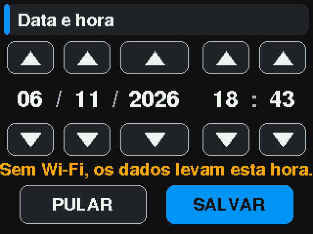

**Figura 13.** A pergunta do fim do boot num aparelho sem rede: a data e a hora do relógio provisório, prontas para acertar.

#### No LCD

alpha O LCD mostra `SIMUT 2.14.0` e `Inicializando` e, depois, uma barra de progresso (capítulo 12).

Num aparelho novo, o boot não espera a rede: no fim dele, o LCD mostra `Sem WiFi` e `Offline` por 3 s e passa às leituras (capítulo 12):

```
 Sem WiFi
    Offline
```

O LCD não mostra a data e a hora, e a pergunta sai só no console. No alpha, o console é o jeito de respondê-la: digite o comando que a linha cita, com a data e a hora locais, pelo console USB ou pelo Bluetooth:

```
SIMUT> conf time 2026-10-01 14:30:00
OK: Hora aplicada (imediato, nao persiste em reboot)
```

A interface web também acerta o relógio, por um ponto de acesso aberto com `ap` (capítulo 10).

#### No Air

air O Air não tem tela. Ao ligar, ele fica acordado (M0), com o console completo pelo USB e pelo Bluetooth e com a interface web. Como as outras imagens, ele não abre o ponto de acesso sozinho. Sem rede configurada, ele escreve no console a mesma linha do relógio provisório, e o comando `time` acerta o relógio (capítulo 10). Sem nenhuma atividade no console ou na web por 5 min, ele começa a hibernar (capítulo 19).

### A senha inicial do administrador

Na primeira partida, o aparelho cria a conta `admin` com uma senha aleatória de 8 caracteres, feita de letras maiúsculas e algarismos, sem `O`, `0`, `I` e `1`. Ele mostra a senha **uma única vez**, no console USB:

```
==============================================
 SEC-003: FACTORY DEFAULTS ATIVADO
 Senha ADMIN inicial: R8TNC3VH
 Trocar no primeiro login (forcado).
==============================================
```

A senha do exemplo é ilustrativa. A moldura sai sempre em português, no meio das linhas de diagnóstico do boot, que começam com `[DBG]`.

- **Nenhuma tela mostra a senha.** O painel, o LCD e a interface web não a exibem. Só o console USB.
- **Ela não volta a aparecer.** O aparelho não guarda a senha em texto: depois do primeiro reinício, a moldura não sai mais, e a senha continua valendo.
- **Abra o programa serial cedo.** O aparelho espera 1 s pelo USB antes de escrever no console. Abra a porta assim que ela aparecer no computador.

Se você não viu a senha, gere outra pelo cabo USB (capítulo 14):

```
SIMUT> system admin reset confirm
Senha admin resetada. Nova senha (unica vez):
 K4XW7PQA
Trocar no 1o login via web (forcado).
```

air No Air, entre antes no modo privilegiado com `enable`. O comando não funciona pelo Bluetooth.

A conta `viewer`, a outra conta de fábrica, não tem senha conhecida. Gere uma senha para ela ou exclua a conta (capítulo 8).

### Pôr o aparelho na rede

#### Pelo ponto de acesso de configuração

release alpha O ponto de acesso é a rede Wi-Fi que o aparelho cria para você configurá-lo. Ele só abre quando você pede. Os detalhes estão no capítulo 9.

1. Abra o ponto de acesso. No console USB, que você já abriu para a senha, digite `ap`. A resposta traz a chave, e o console mostra também o nome da rede:

   ```
   SIMUT> ap

   [AP] SSID: simut_SETUP
   [AP] PSK : M7TQ4XH2RP   (WPA2)
   [AP] URL : http://192.168.4.1
   OK: Modo AP iniciado (WPA2). Senha: M7TQ4XH2RP
   Conecte-se ao AP e acesse http://192.168.4.1
   ```

   Na release, o item 8 do menu do painel, **Modo de Configuração**, faz o mesmo, com uma conta que tenha a permissão **Rede** no painel, e o painel passa a mostrar a rede e a chave (capítulo 11). No painel Ângulo, a linha se chama **Modo de configuração** (capítulo 11A). Na alpha, o `ap` funciona também pelo Bluetooth, e o LCD alterna o endereço, a rede e a chave (capítulo 12).
2. No celular ou no computador, conecte-se à rede `simut_SETUP` com a chave.
3. Abra `http://192.168.4.1`. A página de entrada aparece.
4. Entre como `admin`, com a senha inicial.
5. Defina a senha nova na página **Bem-vindo!** (capítulo 13).
6. Abra a página **Rede**, toque em **Buscar**, escolha a sua rede e digite a senha dela (capítulo 9).
7. Toque em **Salvar e reiniciar** na barra de topo.
8. Volte o celular ou o computador para a sua rede.

O aparelho reinicia e entra na rede. Se a senha da rede estiver errada, o aparelho fica tentando a rede pela escada de reconexão, e o ponto de acesso não volta sozinho: abra-o de novo e refaça a configuração (capítulo 9). Sem rede configurada, o ponto de acesso fica aberto até você gravar uma rede ou reiniciar o aparelho.

A chave do ponto de acesso é sempre a mesma para aquele aparelho, mesmo depois de um reset de fábrica. Anote-a: ela serve toda vez que o aparelho precisar do ponto de acesso.

Com o ponto de acesso aberto, o painel da release passa ao terminal da tela de boot e mostra o nome real da rede, `simut_SETUP` de fábrica, `PSK` seguido da chave, **Acesse no celular: 192.168.4.1** e **AP Ativo! Reinicie a placa para sair.** O LCD do alpha alterna três páginas, com o endereço, a rede e a chave. O aparelho continua medindo com o ponto de acesso aberto (capítulo 9).

[figure not shown]

**Figura 14.** O painel com o ponto de acesso aberto: a rede, a chave e o aviso de AP ativo ficam na tela.

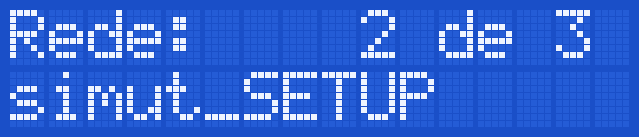

**Figura 15.** O LCD de uma alpha com o ponto de acesso aberto pelo comando `ap`: a página com o nome da rede.

#### Pelo console

Sem celular à mão, grave a rede pelo console USB.

release alpha No console de emergência:

```
SIMUT> system ssid MinhaRede
OK: SSID salvo. Use 'reload confirm' para reconectar.
SIMUT> system pass senha-da-rede
OK: Senha salva. Use 'reload confirm' para reconectar.
SIMUT> reload confirm
```

air No console completo do Air:

```
SIMUT> enable
SIMUT# configure terminal
SIMUT(config)# system ssid MinhaRede
SIMUT(config)# system pass senha-da-rede
SIMUT(config)# end
SIMUT# reload confirm
```

Atenção

**Sem espaços no console.** O console grava só até o primeiro espaço: `system ssid Minha Rede` grava `Minha`. Uma rede ou uma senha com espaço se grava pela página **Rede**, pelo ponto de acesso. No Air, use `enable` e `ap` e siga os passos do ponto de acesso.

air O Air mede e grava o histórico mesmo sem rede. A rede serve para a telemetria e para a hora certa (capítulo 19).

### Encontrar o endereço do aparelho

Na sua rede, o aparelho recebe um endereço IP do roteador. Para descobri-lo:

| Onde | Como |
| --- | --- |
| Console USB, todas as imagens | `show net status`: a linha `IP:` (capítulo 14) |
| alpha LCD | `Conectado!` e o endereço, por 3 s, no fim do boot (capítulo 12) |
| release Nome na rede | `http://simut.local`, com o nome do aparelho seguido de `.local` (capítulo 9) |
| release Painel | **Configurações > Status do Sistema**, página 2, linha `IP` (capítulo 11; no Pico 2 W, veja o capítulo 11A) |
| Roteador | A lista de aparelhos conectados do roteador |

Com o NTP ligado e sem servidor de hora alcançável, o nome `.local` não responde (Idioma, fuso e hora).

### A primeira entrada na web

1. No navegador, abra o endereço do aparelho, como `http://192.0.2.10`.
2. Entre como `admin`.
3. Se você ainda não trocou a senha inicial, a página **Bem-vindo!** pede a senha nova: pelo menos 8 caracteres, com letra, algarismo e símbolo (capítulo 13).

Sem pacote de idioma, a interface aparece em inglês. O resto da interface está no capítulo 13.

### Idioma, fuso e hora

1. **Idioma.** Envie `language_pt-BR.lng` para a pasta `/lang`, pela página **Arquivos**, e reinicie o aparelho (capítulo 3). O idioma de fábrica do aparelho é o português: depois do reinício com o pacote na pasta, o painel e a interface web ficam em português. O console já responde em português. release O idioma do painel muda em **Configurações > Idioma** (capítulo 11; no Pico 2 W, capítulo 11A); o da web, no seletor de cada navegador (capítulo 13).
2. **Fuso.** O de fábrica é −3, o de Brasília. Para outro, mude o **Fuso Horário** na página **Configurações**, seção **Identidade**, e toque em **Salvar e reiniciar** (capítulo 10).
3. **Hora.** O NTP vem ligado e acerta o relógio pela internet. Numa rede sem acesso à internet, aponte o aparelho para um servidor de hora da própria rede ou acerte o relógio à mão: sem o primeiro acerto, o aparelho não termina de entrar na rede, e a telemetria espera (capítulo 10). Num aparelho que vai funcionar sem Wi-Fi, acerte a hora à mão depois de cada boot: em qualquer imagem, com o comando `time` no console; na release, também pela pergunta do boot ou pelo item 13 do menu, **Data e hora** (capítulo 10).

### O primeiro sensor

1. Abra **Configurações** e role até **Sensores e GPIO**.
2. Toque em **+ Adicionar slot de sensor**.
3. Escolha o tipo, o GPIO de cada pino, o **ID de Hardware** e o **Nome**, e ligue **Ativo**.
4. Toque em **Concluído** e depois em **Salvar e reiniciar**.

O passo a passo completo, com a busca de sondas e a calibração, está no capítulo 6. O sensor aparece no **Painel de Controle** depois das primeiras leituras.

release O mínimo e o máximo do cartão no painel dependem de o número do slot coincidir com o do GPIO. Veja a atenção de Os cartões antes de escolher os pinos; no Pico 2 W, veja Mínimo e máximo.

air No Air, configure os sensores pela web com o aparelho acordado ou pelos comandos `sensor` do console (capítulo 14).

### O PIN do painel

release O painel não usa senha: cada pessoa se identifica com a conta e um PIN. A conta `admin` sai de fábrica com o PIN `1234`, que precisa ser trocado no primeiro uso (capítulo 8).

1. Na tela inicial, toque em **CFG**, na barra de botões de baixo, logo depois do último sensor (capítulo 11). No painel Ângulo, toque na engrenagem, que vem logo depois do último sensor (capítulo 11A).
2. Na tela **Quem está usando o painel?**, toque em `admin` e depois em **ENTRAR**.
3. Digite `1234` e toque em **ENTRAR**.
4. O painel abre a tela **Novo PIN**. Digite o PIN novo e toque em **ENTRAR**.

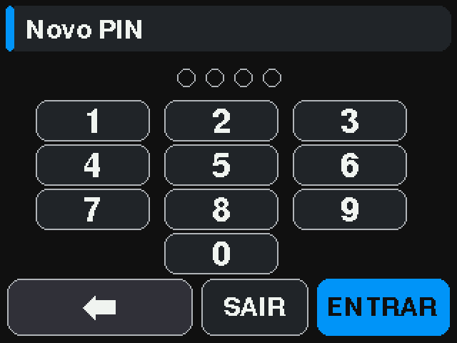

**Figura 16.** A troca obrigatória do PIN de fábrica: a tela Novo PIN abre direto depois do 1234.

O tamanho mínimo e os caracteres do PIN seguem a política de PIN (capítulo 8). Para cada operador, crie uma conta com PIN e só as permissões de que ele precisa (capítulo 8).

### Pronto para usar

Confira antes de entregar o aparelho:

1. A senha do `admin` foi trocada e está guardada em lugar seguro.
2. A conta `viewer` tem senha nova ou foi excluída (capítulo 8).
3. O aparelho está na rede, e você sabe o endereço dele (Encontrar o endereço).
4. A chave do ponto de acesso está anotada (capítulo 9).
5. A hora está certa e o fuso é o do local (capítulo 10). release No painel, a data e a hora da barra de cima não têm o `?` do relógio provisório.
6. Há um só pacote de idioma na pasta `/lang` (capítulo 3).
7. Cada sensor aparece no **Painel de Controle** com leituras plausíveis (capítulo 6).
8. Os limites de alarme de cada sensor estão definidos (capítulo 7).
9. release O PIN do `admin` não é mais `1234`, e cada operador tem a sua conta com PIN (capítulo 8).
10. A telemetria e a linha de alarmes estão configuradas, se houver servidor (capítulo 21, capítulo 22).
11. Um backup da configuração foi baixado (capítulo 17).
12. air O ciclo de hibernação foi conferido (capítulo 19).

Voltar ao sumário

Parte II

## Configurar

Capítulo 5

## Configuração pela web: os três botões e a página Configurações

Este capítulo explica como a interface web grava uma alteração de configuração, o que cada um dos três botões de gravação faz e quando o aparelho precisa reiniciar. Depois, percorre a página **Configurações** campo a campo. É para quem configura o aparelho pelo navegador.

### Como uma alteração é gravada

Nas páginas de configuração, nada é gravado enquanto você digita. Cada campo alterado vira uma alteração **preparada**, guardada na aba do navegador. As páginas **Configurações**, **Alarmes e Sons**, **Telemetria**, **Rede** e **Usuários** preparam alterações no mesmo conjunto: você pode alterar um limite de alarme, passar para a página **Rede**, alterar o DNS e gravar tudo de uma vez.

O conjunto preparado:

- sobrevive à troca de página e ao recarregar a página, dentro da mesma aba;
- some se você fechar a aba, tocar em **Sair** ou entrar de novo;
- não é visto por outra aba, outro navegador ou outra pessoa.

Na primeira alteração de um conjunto novo, um aviso lembra: **Clique em “Salvar e Reiniciar” para aplicar as alterações.** (*Click “Save & Restart” to apply your changes.*). A partir daí, a barra de topo mostra um selo e os botões de gravação (capítulo 13). No celular, eles ficam numa barra fixa no rodapé.

Os campos de cada página mostram o valor gravado no aparelho, com as alterações preparadas por cima. O que aparece na página é o que será gravado.

#### O ensaio: o aparelho decide

Cerca de 0,6 s depois da última alteração, a página envia o conjunto preparado ao aparelho como um **ensaio** (o parâmetro `_dry=1`). O aparelho aplica todas as verificações de faixa e de formato numa cópia da configuração, compara a cópia com a configuração em uso e responde quais grupos de configuração mudariam e se algum deles exige reinício. Nada é gravado e nada reinicia.

Quem decide é o aparelho, não a página. Um campo digitado de volta ao valor atual não conta como mudança.

O selo da barra de topo mostra a resposta:

| Selo | Quando | Botões oferecidos |
| --- | --- | --- |
| **Alterações não salvas** (*Unsaved changes*) | O ensaio ainda não respondeu, ou o aparelho recusou o ensaio | Só **Salvar e reiniciar** |
| **Reinicia por:** (*Restarts for*) seguido dos grupos | O ensaio respondeu que algum grupo exige reinício | Só **Salvar e reiniciar** |
| **Não exige reinício** (*No restart needed*) | O ensaio respondeu que tudo se aplica sem reiniciar | **Testar**, **Aplicar agora** e **Salvar e reiniciar** |

O aparelho recusa o ensaio quando o conjunto inclui slots de sensor ou calibração (capítulo 6). Essas alterações só se gravam com **Salvar e reiniciar**. Contas (capítulo 8) passam pelo ensaio desde a v2.10.0, mas sem **Testar**: uma conta não se testa. No SIMUT Air, o ensaio é sempre recusado (No SIMUT Air).

Os grupos aparecem com o nome curto que o aparelho usa, em inglês, como `time` ou `alarms`. Com **Não exige reinício**, pare o ponteiro sobre o selo para ver a lista dos grupos. A tabela de Os grupos de configuração diz o que cada nome inclui.

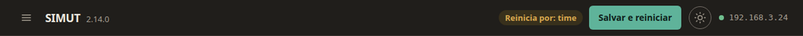

**Figura 17.** Uma alteração que exige reinício: o selo diz Reinicia por: time e só o botão Salvar e reiniciar aparece.

#### Os três botões

| Botão | O que faz | Depois |
| --- | --- | --- |
| **Testar** (*Test*) | Aplica as alterações à configuração em uso sem gravá-las (`_nosave=1`) | O conjunto continua preparado. Um reinício volta aos valores gravados |
| **Aplicar agora** (*Apply now*) | Grava e aplica, sem reiniciar | O conjunto preparado é esvaziado |
| **Salvar e reiniciar** (*Save & restart*) | Grava e reinicia o aparelho, sempre (`_reboot=1`) | O conjunto preparado é esvaziado e a página se recarrega |

**Testar** e **Aplicar agora** só aparecem quando o ensaio respondeu **Não exige reinício**. **Salvar e reiniciar** aparece sempre que há alteração preparada, e reinicia mesmo quando a alteração se aplicaria sem reinício.

Para experimentar uma alteração sem gravá-la:

1. Faça a alteração, por exemplo um limite de alarme.
2. Espere o selo mostrar **Não exige reinício**.
3. Toque em **Testar**.

O aviso **Aplicado SEM salvar — um reinício desfaz** (*Applied WITHOUT saving — a restart undoes it*) aparece, seguido dos grupos aplicados. A barra de gravação continua visível, porque a alteração ainda não está gravada. Para mantê-la, toque em **Aplicar agora**. Para desistir dela, toque em **Sair** ou feche a aba e reinicie o aparelho.

Atenção

**Testar não sobrevive a um reinício nem a uma falta de energia.** Qualquer reinício, pedido ou não, volta aos valores gravados. Use **Testar** para experimentar, não para configurar.

Para gravar sem reiniciar:

1. Faça as alterações.
2. Espere o selo mostrar **Não exige reinício**.
3. Toque em **Aplicar agora**.

O aviso **Aplicado e salvo** (*Applied and saved*) aparece, seguido dos grupos aplicados. A sessão continua aberta e o aparelho não sai do ar.

Para gravar e reiniciar:

1. Faça as alterações.
2. Toque em **Salvar e reiniciar**.
3. Leia a confirmação e toque em **OK**.

A confirmação diz: **Isto salvará todas as alterações e reiniciará o sistema. O dispositivo ficará offline por ~10 segundos. Qualquer gravação de histórico/log em andamento será interrompida. Continuar?** Depois de **OK**, aparece **Salvo! Reiniciando sistema…** (*Saved! Restarting system…*) e a página se recarrega sozinha cerca de 12 s depois (O que um reinício custa).

Se há uma calibração preparada (capítulo 6), **Salvar e reiniciar** primeiro envia a calibração ao aparelho e só depois grava o resto. Se a calibração falha, nada é gravado e aparece **Erro na calibração:** seguido do motivo, ou **Tempo esgotado na calibração. Tente novamente.**

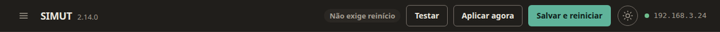

**Figura 18.** Uma alteração que se aplica sem reinício: o selo diz Não exige reinício e os três botões aparecem.

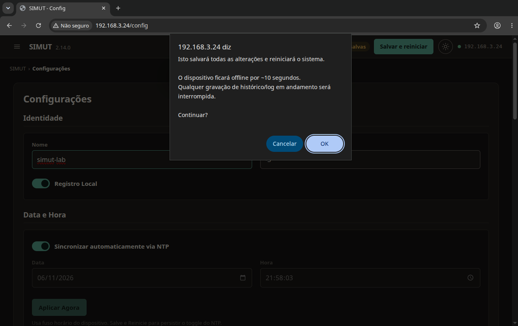

**Figura 19.** A confirmação de Salvar e reiniciar, que avisa quanto tempo o aparelho fica fora do ar.

#### Os grupos de configuração

O aparelho classifica cada alteração comparando a configuração de antes com a de depois, campo por campo. Um grupo só se aplica sem reinício quando o firmware relê aqueles campos a cada uso, ou tem uma função que empurra o valor novo para quem o usa. Todo o resto reinicia. Um campo que não pertence a nenhum grupo conhecido cai em `unclassified` e também reinicia. Quatro campos que nenhuma parte do firmware lê são a exceção: **Amostra (ms)**, **Registro Local** e dois que só o arquivo de configuração carrega. O aparelho os reconhece, eles não entram em grupo nenhum e gravam sem reiniciar, desde a v2.7.4.

| Grupo | O que inclui | Onde se altera | Sem reinício? |
| --- | --- | --- | --- |
| `alarms` | Limites de alarme por canal e alarmes ligados por slot | **Alarmes e Sons** (capítulo 7) | Sim |
| `maint` | Janelas de manutenção | **Alarmes e Sons** (capítulo 7) | Sim |
| `alarm_tel` | Linha de alarmes: ligada, fila, formato, modelos, `Content-Type` e caminho | **Telemetria** (capítulo 22) | Sim |
| `telemetry` | Telemetria pelo lado HTTP: servidor, porta, caminho, chave, lote mínimo e máximo, formato, modelos e `Content-Type` | **Telemetria** (capítulo 21) | Sim |
| `users` | Política de PIN do painel | **Configurações** (Hardware) | Sim |
| `users` | Contas | **Usuários** (capítulo 8) | Sim, sem **Testar** |
| `display` | Tema e idioma do painel | Nenhuma página grava estes campos por aqui | Sim |
| `identity` | Nome do aparelho | **Configurações** | Não |
| `time` | Fuso horário e servidor NTP | **Configurações**, **Rede** | Não |
| `sensing` | Resolução do DS18B20 | **Configurações** | Não |
| `slots` | Tipo, GPIOs, identificação e nome dos slots de sensor | **Configurações** (capítulo 6) | Não: o ensaio é recusado |
| `net` | Wi-Fi, DHCP, IP estático, DNS primário | **Rede** (capítulo 9) | Não |
| `mqtt` | Transporte, conta, senha e opções MQTT, e o TLS da telemetria | **Telemetria** (capítulo 21) | Não |
| `web` | A área de extensão da configuração: porta web, conexões persistentes, sons, intervalo do histórico, NTP ligado, DNS automático e secundário, syslog e Home Assistant | Várias | Não |
| `unclassified` | Qualquer diferença fora dos grupos acima | — | Não |

O tema do painel tem gravação própria, pelo **Painel de Controle**, e não passa por estes botões (capítulo 13).

Nota

**Por que esses grupos reiniciam.** Vários subsistemas leem a configuração uma única vez, ao ligar: o servidor web fixa porta e protocolo ao subir, o cliente MQTT fixa o servidor, o certificado da telemetria é lido uma vez e os slots de sensor montam o circuito de leitura inteiro. Reiniciar é o único jeito de todos relerem o valor novo.

Nota

**Até a v2.9.0, o ensaio não enxergava a área de extensão.** O intervalo do histórico, o interruptor do NTP, os campos do syslog, o Home Assistant Discovery, o DNS automático, o DNS secundário e as conexões persistentes ficavam fora da cópia que ele compara: o selo podia mostrar **Não exige reinício**, e **Aplicar agora** reiniciava mesmo assim. Desde a v2.10.0, esses campos entram no ensaio pelo grupo `web`, e o selo mostra **Reinicia por: web**.

#### Valores recusados

O aparelho confere cada campo antes de gravar. Um valor fora da faixa ou com formato errado é descartado: o campo mantém o valor anterior, e o resto da gravação continua.

- Depois de **Testar** ou **Aplicar agora**, o aviso **Campos não aplicados:** (*Fields not applied*) lista as chaves recusadas, como `s_int` ou `net.dns2`.
- Depois de **Salvar e reiniciar**, a página se recarrega sem esse aviso. Confira os campos alterados depois do reinício.

Alguns erros recusam a gravação inteira, e nada muda. O aviso é **Falha ao salvar.** (*Save failed.*) seguido do motivo e, quando existe, da seção entre parênteses. Os casos:

| Resposta | Motivo |
| --- | --- |
| `Alarm limit outside channel range` | Um limite de alarme fora da faixa possível do canal (capítulo 7) |
| `Alarm limit is not a number` | Um limite de alarme que não é número. Só chega por um cliente da API: a página sempre manda números |
| O slot e o GPIO recusados, como `slot 4: GP2 already used by slot 2` | Conflito na atribuição de GPIO (capítulo 6) |
| `Forbidden (<seção>)` | A conta não tem a permissão daquela seção (tabela abaixo) |
| `Password change required` | A conta ainda precisa trocar a senha (capítulo 13) |
| `Display in use. Retry shortly.` | Alguém tocou no painel há menos de 5 s. Espere e tente de novo |
| `Bad payload` | O conjunto preparado passou de 6.144 bytes. Grave em partes |

Cada seção do conjunto exige a sua permissão, e a gravação é tudo ou nada: se uma seção é proibida, nenhuma é gravada.

| Seção | Páginas que a preparam | Permissão |
| --- | --- | --- |
| `sys` | **Configurações** e **Telemetria** | **Sistema** PERM_SYS_CONFIG |
| `slots`, `calib` | **Configurações** (sensores) | **Sistema** PERM_SYS_CONFIG |
| `alarms` | **Alarmes e Sons** | **Sistema** PERM_SYS_CONFIG |
| `net` | **Rede** | **Rede** PERM_NET_CONFIG |
| `users` | **Usuários** | **Usuários** PERM_USER_MGR |

#### O que um reinício custa

Um **Salvar e reiniciar** leva o aparelho para fora do ar por cerca de 10 s. Na ordem:

1. O painel mostra **Aplicando configurações…** e depois **Reiniciando o sistema…**, cerca de 1,5 s cada.
2. O aparelho grava a configuração, registra o evento e responde à página.
3. O aparelho reinicia. Uma gravação de histórico ou de log em andamento é interrompida.
4. A página se recarrega cerca de 12 s depois e mostra a página de entrada, porque um reinício encerra todas as sessões (capítulo 13).

Dois casos mudam o passo 4:

- **Porta web alterada:** a página avisa **Salvo. Redirecionando para nova porta…** e, cerca de 15 s depois, abre o endereço com a porta nova (capítulo 9).
- **Conta criada ou senha redefinida:** antes de recarregar, a página mostra a senha provisória de cada conta. Anote-a: ela não aparece de novo (capítulo 8).

Depois do reinício, o aparelho se reconecta ao Wi-Fi, acerta o relógio de novo (capítulo 10) e retoma a telemetria.

O log de eventos registra cada gravação com o código 303 (**Config alterada**), com um destes textos:

| Texto | Botão |
| --- | --- |
| `Admin committed changes — rebooting` | **Salvar e reiniciar**, ou **Aplicar agora** quando algum grupo exigiu reinício |
| `Admin committed changes — applied live` | **Aplicar agora** |
| `Admin committed changes — applied live [nosave]` | **Testar** |

#### No SIMUT Air

air

O Air recusa o ensaio e o **Testar**: a imagem do Air está no limite de memória de programa, e os dois caminhos que trabalham numa cópia da configuração ficaram de fora. Na barra de topo do Air, o selo fica em **Alterações não salvas** e só **Salvar e reiniciar** aparece. Toda gravação pela web reinicia o Air.

Lembre que a interface web do Air só existe enquanto ele está acordado em M0 (capítulo 13, capítulo 19).

#### Pela API

Os três botões usam a mesma rota, `POST /api/commit_all`, com o conjunto preparado no campo `_payload`. O que muda é o parâmetro extra:

| Botão | Parâmetro |
| --- | --- |
| Ensaio da página | `_dry=1` |
| **Testar** | `_nosave=1` |
| **Aplicar agora** | nenhum |
| **Salvar e reiniciar** | `_reboot=1` |

A resposta diz o que aconteceu. Um ensaio de fuso horário, por exemplo:

```json
{"status":"dry","reboot":true,"applied":["time"],"reboot_for":["time"]}
```

Um integrador pode usar o ensaio para validar uma configuração antes de mandá-la a vários aparelhos. O formato completo está no capítulo 26.

### A página Configurações

A página **Configurações** (*System Config*, rota `/config`) exige a permissão **Sistema**. Ela tem sete seções, nesta ordem; a alpha e o Air não têm a sexta:

1. **Identidade** (*General Identity*)
2. **Data e Hora** (*Date & Time*)
3. **Hardware** (*Hardware & Sampling*)
4. **Sensores e GPIO** (*Sensors & GPIO*)
5. **Syslog Remoto (Auditoria)** (*Remote Syslog (Audit Trail)*)
6. release **Calibração do Touch** (*Touch Calibration*)
7. **Reiniciar** (*Restart*)

As cinco primeiras preparam alterações para os botões da barra de topo. A página não tem botão de gravar próprio. **Calibração do Touch** e **Reiniciar** agem na hora, cada uma com botão próprio.

Se a página não consegue ler a configuração do aparelho, ela mostra uma faixa vermelha: **Não foi possível carregar as configurações atuais. Os campos estão desabilitados para evitar salvar valores em branco sobre a sua configuração.** Os campos ficam desabilitados, de propósito. Toque em **Tentar novamente** (*Retry*). A página já tenta três vezes antes de mostrar a faixa.

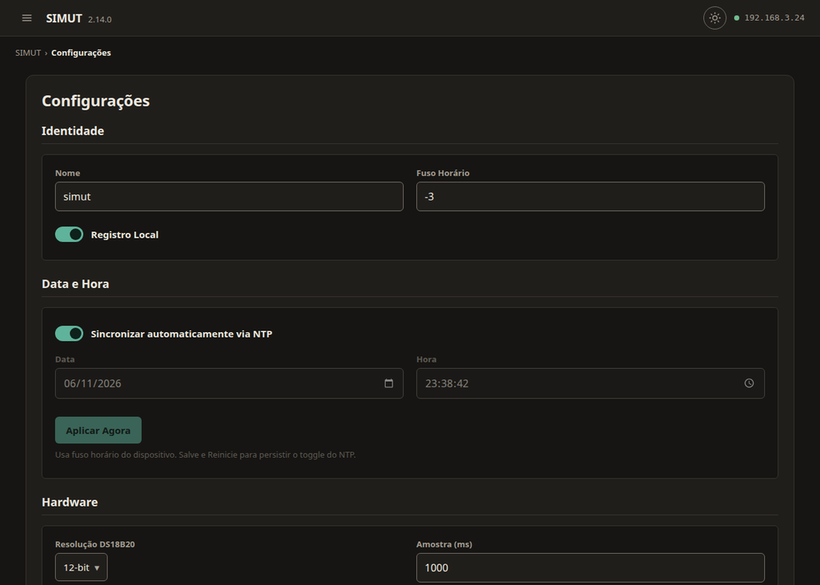

**Figura 20.** A página Configurações aberta, com as seções Identidade e Data e Hora.

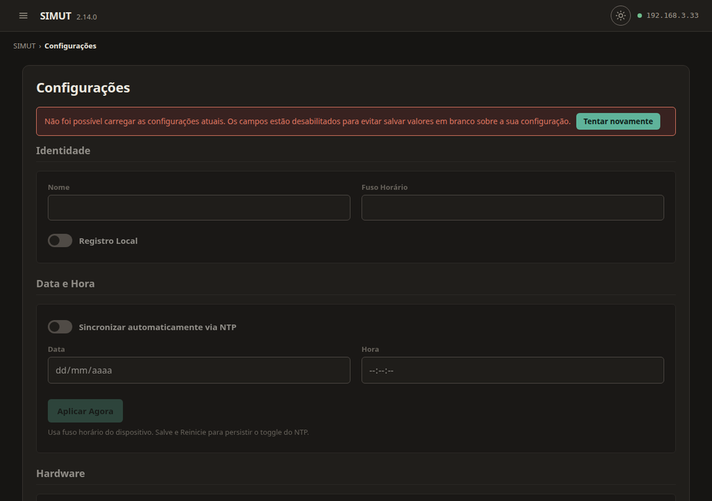

**Figura 21.** A faixa de erro de carga: os campos ficam desabilitados para que nada em branco seja gravado.

#### Identidade

| Campo | O que faz | Faixa e formato | Fábrica | Aplicação | Chave |
| --- | --- | --- | --- | --- | --- |
| **Nome** (*Device Name*) | Nome do aparelho | 1 a 31 caracteres, sem aspas `"` nem barra invertida `\`; espaços nas pontas são removidos | `simut` | Reinicia (`identity`) | `name` |
| **Fuso Horário** (*Timezone Offset (Hours)*) | Diferença do horário local para o UTC, em horas inteiras | −12 a +14 | −3 | Reinicia (`time`) | `tz` |
| **Registro Local** (*Enable Local Logging*) | Preferência de registro local, sem efeito | Ligado ou desligado | Ligado | Grava sem reiniciar | `log` |

O **Nome** aparece em vários lugares:

- no nome da rede do ponto de acesso de configuração, seguido de `_SETUP` (capítulo 9);
- no endereço mDNS, seguido de `.local` (release, capítulo 9);
- no nome Bluetooth (alpha air, capítulo 14);
- no campo de origem das mensagens de syslog (capítulo 25) e no rótulo das métricas Prometheus (capítulo 24);
- na etiqueta `{DEV}` da telemetria (capítulo 21);
- em `show system info`, no console.

Como o nome vira endereço de rede e nome de rede Wi-Fi, prefira letras sem acento, números e hífen.

O **Fuso Horário** não tem horário de verão nem frações de hora. Detalhes, e um efeito colateral de digitar neste campo, estão no capítulo 10.

Atenção

**Registro Local não desliga nada nesta versão.** O aparelho grava a preferência e a mostra em `show system info` (`Logging: ATIVO` ou `INATIVO`), mas nenhuma parte do firmware a consulta: o log de eventos e o histórico continuam gravados com ela desligada. Desde a v2.7.4, alterá-la grava sem reiniciar; até a v2.7.3, reiniciava o aparelho, e nada mais.

#### Data e Hora

| Campo | O que faz | Faixa e formato | Fábrica | Aplicação | Chave |
| --- | --- | --- | --- | --- | --- |
| **Sincronizar automaticamente via NTP** (*Synchronize automatically via NTP*) | Liga o acerto do relógio pela rede | Ligado ou desligado | Ligado | Reinicia (`web`) | `ntp_enabled` |
| **Data** (*Date*) | Data para o acerto manual | A partir de 01/01/2026 | A data do aparelho ao abrir a página | Na hora, pelo botão **Aplicar Agora** | — |
| **Hora** (*Time*) | Hora para o acerto manual, com segundos | `hh:mm:ss` | A hora do aparelho ao abrir a página | Na hora, pelo botão **Aplicar Agora** | — |

O botão **Aplicar Agora** (*Apply Now*) desta seção acerta o relógio imediatamente, sem passar pela barra de topo e sem reiniciar. Ele interpreta a data e a hora digitadas no fuso do campo **Fuso Horário**, como ele está na página. A resposta aparece abaixo do botão: **Hora aplicada.** (*Time applied.*), **Falhou ao aplicar.** (*Failed to apply.*) ou, com um campo vazio, **Preencha data e hora.** (*Fill date and time.*).

Com o NTP ligado, os campos de data e hora ficam esmaecidos, mas continuam editáveis: o acerto manual vale até a próxima sincronização. A dica abaixo do botão lembra: **Usa fuso horário do dispositivo. Salve e Reinicie para persistir o toggle do NTP.**

Nota

**Mexer em Data ou Hora também faz a barra de gravação aparecer.** Os dois campos ficam no mesmo formulário e entram no conjunto preparado, mas o aparelho os ignora na gravação. Para acertar o relógio, use o **Aplicar Agora** da seção. Se a barra apareceu só por causa deles, toque em **Sair** e entre de novo para descartar o conjunto.

O funcionamento do relógio, do NTP e do acerto manual está no capítulo 10.

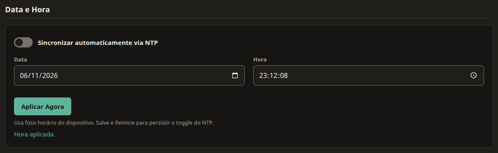

**Figura 22.** A seção Data e Hora com o NTP desligado, depois de um acerto manual.

#### Hardware

[output not shown]

Sobre a resolução: nesta versão, o aparelho espera 750 ms por leitura do DS18B20 em qualquer resolução. Baixar a resolução reduz a precisão sem encurtar a leitura. Detalhes no capítulo 6.

A dica abaixo de **Intervalo Histórico (min)** diz: **1 a 1440 min (24h). Padrão: 1.** air No Air, esse intervalo é também o intervalo entre despertares, porque a tarefa principal de cada despertar é gravar um registro (capítulo 19).

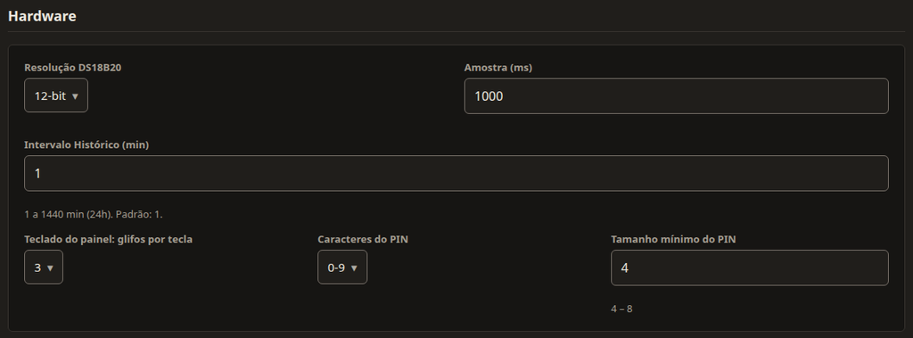

**Figura 23.** A seção Hardware na imagem release, com a política de PIN do painel.

#### Sensores e GPIO

A seção **Sensores e GPIO** (*Sensors & GPIO*) configura os 16 slots de sensor. Ela é descrita inteira no capítulo 6. Em resumo:

- a dica **GP0–GP15 estão disponíveis para sensores; GP16 em diante pertencem ao display, ao touch e ao buzzer.**;
- um mapa dos GPIOs em uso;
- a tabela dos slots, com as colunas **Slot**, **Tipo**, **GPIOs**, **ID de Hardware** e **Nome**;
- os botões **+ Adicionar slot de sensor** e **Procurar sondas**;
- o editor de slot, com **Tipo**, **Nome**, **ID de Hardware**, **Estado** (**Ativo** e **Alarmes habilitados**), **Atribuição de GPIO**, **Calibração**, **Gravação no histórico** e **Hardware**, e os botões **Liberar slot**, **Descartar alterações** e **Concluído**.

Alterações de slot e de calibração só se gravam com **Salvar e reiniciar**. Com os 16 slots em uso, a página diz **Os 16 slots estão em uso. Libere um para adicionar outro.**

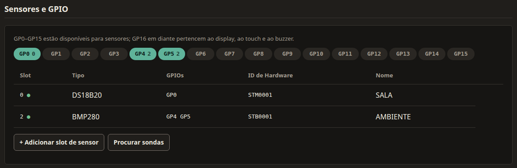

**Figura 24.** A seção Sensores e GPIO, com o mapa de GPIOs e a tabela de slots. O editor de slot está no capítulo 6.

#### Syslog Remoto (Auditoria)

Esta seção envia os eventos do log a um coletor syslog na rede, para que a trilha de auditoria exista também fora do aparelho. A dica diz que o envio segue a RFC 5424 sobre UDP, que o servidor é um IPv4 da rede local e não um nome, e que não há garantia de entrega.

| Campo | O que faz | Faixa e formato | Fábrica | Aplicação | Chave |
| --- | --- | --- | --- | --- | --- |
| **Habilitar encaminhamento syslog** (*Enable syslog forwarding*) | Liga o envio | Ligado ou desligado | Desligado | Reinicia (`web`) | `slog_en` |
| **IP do Coletor** (*Collector IP*) | Endereço do coletor | IPv4, como `192.0.2.10`; vazio desliga | Vazio | Reinicia (`web`) | `slog_srv` |
| **Porta UDP** (*UDP Port*) | Porta do coletor | 1 a 65535 | 514 | Reinicia (`web`) | `slog_port` |
| **Nível Mínimo** (*Minimum Level*) | Menor nível enviado | Debug, Info, Warning, Error ou Fatal | Info | Reinicia (`web`) | `slog_lvl` |

Com o interruptor ligado e o **IP do Coletor** vazio, nada é enviado. O formato das mensagens e a configuração do coletor estão no capítulo 25.

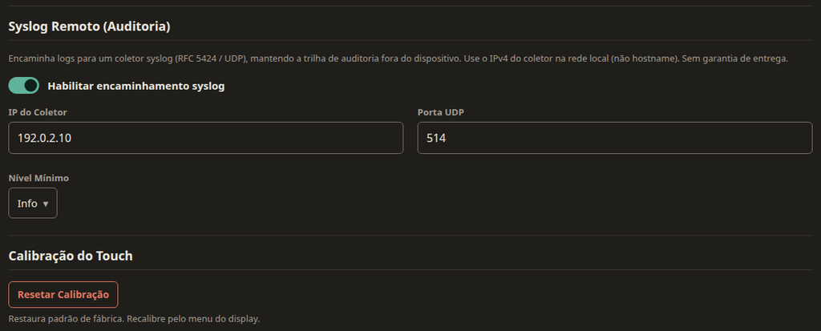

#### Calibração do Touch

release

O botão **Resetar Calibração** (*Reset Touch Calibration*) apaga a calibração do toque guardada e abre o assistente de calibração no painel. Ele age na hora, sem passar pela barra de topo:

1. Toque em **Resetar Calibração**.
2. Confirme em **Resetar calibração do touch para padrão de fábrica?**
3. Vá até o painel e siga os passos do assistente (capítulo 11; no Pico 2 W, capítulo 11A).

O aviso **Calibração resetada. Recalibre pelo display.** confirma. Se alguém tocou no painel há menos de 5 s, aparece **Display em uso. Tente novamente em alguns segundos.** O log de eventos registra `Touch calibration reset via web` com o código 303.

A seção só aparece na imagem release, a única com painel de toque. Até a v2.7.3 ela aparecia também na alpha e no Air, onde o botão apagava o registro de calibração guardado e dizia que o assistente estava rodando num painel que não existe.

#### Reiniciar

Desde a v2.7.3, a última seção da página tem o botão **Reiniciar sem salvar** (*Restart without saving*). Ele reinicia o aparelho sem gravar nada: o que está pendente na barra de topo é descartado, e o que foi aplicado com **Testar** também se desfaz, porque o aparelho volta com a configuração gravada. Ele age na hora, sem passar pela barra de topo:

1. Toque em **Reiniciar sem salvar**.
2. Confirme em **Reiniciar agora SEM salvar?** O aviso lembra que as alterações não salvas nesta página serão perdidas e que o aparelho fica fora do ar por cerca de 10 s.

O aviso **Reiniciando…** confirma, e a página se recarrega cerca de 12 s depois, na página de entrada, porque o reinício encerra as sessões. Medido em 25/09/2026: o aparelho saiu do ar 3,3 s depois do clique e voltou a responder aos 26,4 s. O log de eventos registra o código 2 (**Reboot solicitado pelo usuário**).

Se alguém tocou no painel há menos de 5 s, aparece **Display em uso. Tente novamente em alguns segundos.** e nada acontece. Se o aparelho recusar o pedido, aparece **Não foi possível reiniciar.** e ele continua no ar.

### Referência rápida

Todos os campos da página **Configurações** que passam pela barra de topo, na seção `sys` de `POST /api/commit_all`. Os campos da página **Telemetria** estão no capítulo 21 e no capítulo 22; os da página **Rede**, no capítulo 9.

| Chave | Campo | Faixa | Fábrica | Grupo |
| --- | --- | --- | --- | --- |
| `name` | **Nome** | 1 a 31 caracteres | `simut` | `identity`, reinicia |
| `tz` | **Fuso Horário** | −12 a +14 | −3 | `time`, reinicia |
| `log` | **Registro Local** | `1` ou `0` | `1` | nenhum, grava sem reiniciar |
| `ntp_enabled` | **Sincronizar automaticamente via NTP** | `1` ou `0` | `1` | `web`, reinicia |
| `res` | **Resolução DS18B20** | 9 a 12 | 12 | `sensing`, reinicia |
| `s_int` | **Amostra (ms)** | 1000 a 60000 | 2000 | nenhum, grava sem reiniciar |
| `h_int` | **Intervalo Histórico (min)** | 1 a 1440 | 1 | `web`, reinicia |
| `pin_kb` | **Teclado do painel: glifos por tecla** | 1 a 3 | 3 | `users`, reinicia |
| `pin_alpha` | **Caracteres do PIN** | 0 (`0-9`) ou 1 (`0-9 A-Z`) | 0 | `users`, reinicia |
| `pin_min` | **Tamanho mínimo do PIN** | 4 ao teto do teclado | 4 | `users`, reinicia |
| `slog_en` | **Habilitar encaminhamento syslog** | `1` ou `0` | `0` | `web`, reinicia |
| `slog_srv` | **IP do Coletor** | IPv4 ou vazio | vazio | `web`, reinicia |
| `slog_port` | **Porta UDP** | 1 a 65535 | 514 | `web`, reinicia |
| `slog_lvl` | **Nível Mínimo** | 0 (Debug) a 4 (Fatal) | 1 (Info) | `web`, reinicia |

As três chaves `pin_*` só existem na imagem release. Nas outras, a página não as envia.

Voltar ao sumário

Capítulo 6

## Sensores e calibração

Este capítulo mostra como dizer ao aparelho quais sensores estão ligados e em quais pinos, como ele valida cada leitura e como corrigir um sensor contra um instrumento de referência. É para quem instala e mantém o aparelho; os limites de alarme de cada grandeza estão no capítulo 7.

### Onde os sensores são configurados

Os sensores ficam na página **Configurações** (*System Config*, rota `/config`), em duas seções:

- **Hardware** (*Hardware & Sampling*): a resolução do DS18B20, o intervalo do histórico e a política de PIN do painel;
- **Sensores e GPIO** (*Sensors & GPIO*): a lista de slots e o editor de cada um.

A página exige a permissão **Sistema** PERM_SYS_CONFIG. A calibração, dentro do editor de slot, exige também a permissão **Calibração** PERM_CALIB; sem ela, o editor abre sem o bloco de calibração e não mostra erro (Requisitos da calibração).

Tudo o que você muda nestas seções fica preparado na aba do navegador até você gravar. Os três botões de gravação estão no capítulo 5. Mudanças de slot e de calibração só são gravadas com **Salvar e reiniciar** (*Save & restart*): o aparelho não aceita testá-las nem aplicá-las sem reiniciar.

Nota

**Por que mexer num sensor reinicia o aparelho.** Tipo, pinos e identificação de um slot montam o circuito de leitura na partida. O aparelho não troca esse circuito com ele funcionando; reinicia e monta de novo.

### A seção Hardware

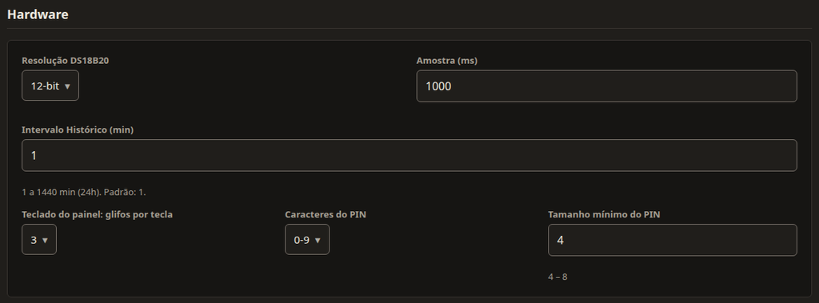

[output not shown]

Os três campos de PIN estão explicados no capítulo 8. Nas imagens alpha e Air, que não têm painel com toque, a página esconde esses três campos.

#### Resolução DS18B20

A resolução define o menor passo da temperatura medida pelo DS18B20: 9 bits é o passo mais grosso e 12 bits o mais fino. O aparelho envia a resolução na partida, pelo GPIO do primeiro slot DS18B20 ativo. Uma sonda DS18B20 ligada a outro GPIO não recebe o ajuste.

O aparelho sempre espera 750 ms pela conversão, que é o tempo da resolução de 12 bits. Uma resolução menor, portanto, não deixa a leitura mais rápida.

#### Amostra (ms)

Atenção

**Este campo não muda nada.** O aparelho valida o valor (de 1000 a 60000 ms), grava e informa na página, mas nenhuma parte do firmware o usa. O ritmo de leitura é fixo por tipo de sensor (Leitura e histórico). Desde a v2.7.4, mudar o campo grava sem reiniciar; até a v2.7.3, provocava um reinício, e nada mais.

#### Intervalo Histórico (min)

É o intervalo entre dois registros do histórico, de 1 min a 1440 min (24 h). O valor de fábrica é 1 min. O que o histórico grava em cada registro está em Leitura e histórico, e o histórico em si no capítulo 15.

Atenção

**Grave o intervalo com Salvar e reiniciar.** A classificação feita antes de gravar não enxerga este campo, e o selo da barra pode mostrar **Não exige reinício** (*No restart needed*) quando ele é a única mudança. Mesmo assim, **Aplicar agora** reinicia o aparelho, e **Testar** não aplica o valor.

### A seção Sensores e GPIO

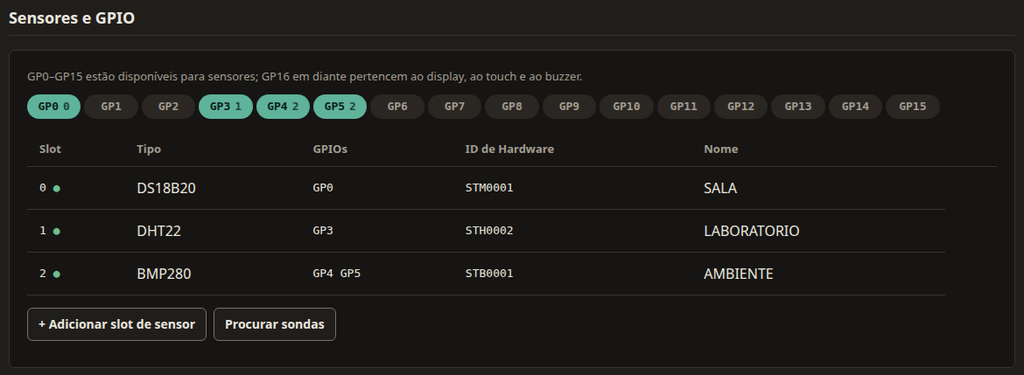

**Figura 27.** A seção Sensores e GPIO. A faixa de GP0 a GP15 mostra quais pinos estão ocupados e por qual slot; a tabela lista só os slots em uso.

A seção mostra, de cima para baixo:

- o aviso **GP0–GP15 estão disponíveis para sensores; GP16 em diante pertencem ao display, ao touch e ao buzzer.**;
- a faixa de pinos, de `GP0` a `GP15`. Um pino ocupado aparece destacado, com o número do slot dono ao lado;
- a tabela de slots;
- os botões **+ Adicionar slot de sensor** (*+ Add sensor slot*) e **Procurar sondas** (*Scan for probes*).

A faixa e a tabela mostram o estado que o aparelho terá depois de gravar, e não o estado gravado: um slot com alteração pendente aparece com fundo destacado.

A tabela tem uma linha por slot em uso:

| Coluna | O que mostra |
| --- | --- |
| **Slot** | O número do slot, de 0 a 15, e um ponto verde quando o slot está ativo |
| **Tipo** | O tipo do sensor |
| **GPIOs** | Os pinos atribuídos, como `GP4 GP5` |
| **ID de Hardware** | A chave do sensor no histórico e na telemetria |
| **Nome** | O nome dado ao slot |

Toque numa linha para abrir o editor daquele slot. Sem nenhum slot em uso, a tabela diz **Nenhum slot de sensor configurado ainda.** Com os 16 slots em uso, o botão de adicionar some e aparece **Os 16 slots estão em uso. Libere um para adicionar outro.** Se a página não conseguir ler os slots do aparelho, mostra **Não foi possível carregar os slots de sensores.**; recarregue a página.

#### Slots

O aparelho tem 16 slots, numerados de 0 a 15. Um slot é uma posição da configuração, não um pino: ele guarda o tipo do sensor, os GPIOs que o sensor usa (de 1 a 4), a identificação e os limites de alarme. O número do slot é a identidade do sensor para o histórico, para o console serial e para a linha de alarmes, por isso a página o mostra.

De fábrica, os 16 slots estão vazios e nenhum GPIO está ocupado.

#### Tipos de sensor

Todas as imagens (release, alpha e Air) trazem os quatro tipos:

| Tipo | Pinos no editor | Grandezas |
| --- | --- | --- |
| DS18B20 | 1: `1-Wire` | Temperatura |
| DHT22 | 1: `Data` | Temperatura e umidade |
| BME280 | 2: `SDA` e `SCL` | Temperatura, umidade e pressão |
| BMP280 | 2: `SDA` e `SCL` | Temperatura e pressão |

Sobre os sensores I²C (BME280 e BMP280):

- **Um por par de pinos.** A leitura aceitaria dois sensores no mesmo par SDA/SCL, em `0x76` e `0x77`, mas a gravação recusa dois slots ativos no mesmo GPIO. Dê a cada sensor o seu par, e siga as regras do I²C do capítulo 2: um segundo sensor em outro par do mesmo periférico é lido pelo PIO, mais devagar.
- **O aparelho confere o chip.** Se você escolheu BME280 e o chip é um BMP280, ou o contrário, o aparelho corrige o tipo na partida pelo identificador do chip e grava a correção.
- **Pares do periférico I²C.** Com SDA e SCL num par que o periférico I²C do RP2040 aceita, a leitura usa esse periférico. Em outros pares, o aparelho lê o sensor pelo PIO do RP2040, sem o periférico. A ligação está no capítulo 2.

### O editor de slot

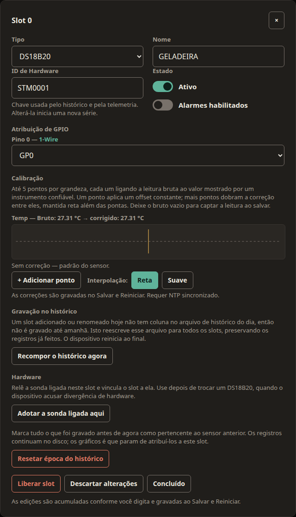

**Figura 28.** O editor de um slot DS18B20: tipo, nome, ID de hardware, estado, o pino 1-Wire, o bloco de calibração e as operações de hardware.

O editor abre sobre a página. Para fechá-lo, toque no **×** do canto, toque fora da caixa ou toque em **Concluído** (*Done*). Fechar não descarta nada: as edições continuam preparadas.

| Campo | O que é | Regras |
| --- | --- | --- |
| **Tipo** (*Type*) | O tipo do sensor. **— vazio —** deixa o slot sem sensor | Os tipos da tabela acima |
| **Nome** (*Name*) | Nome livre, mostrado no painel, na página e nos gráficos | Até 31 caracteres, sem aspas, sem barra invertida e sem caracteres de controle |
| **ID de Hardware** (*Hardware ID*) | A chave do sensor no histórico e na telemetria | De 1 a 15 caracteres: letras sem acento, dígitos, `_` e `-`. Obrigatório num slot ativo |
| **Ativo** (*Active*) | Liga o slot. Só um slot ativo ocupa GPIOs e é lido | Exige tipo, todos os pinos e o ID de hardware |
| **Alarmes habilitados** (*Alarms enabled*) | Liga os alarmes de limite do slot (capítulo 7) | Ligado de fábrica |
| **Atribuição de GPIO** (*GPIO assignment*) | Um seletor por pino do tipo, como **Pino 0 — SDA** | `GP0` a `GP15`. Um GPIO de outro slot ativo aparece desativado, como `GP7 (slot 3)` |

Abaixo dos campos, o editor mostra, nesta ordem:

- o bloco **Calibração** (*Calibration*), só para slots ativos já gravados e só para contas com a permissão **Calibração** (Calibração);
- **Gravação no histórico** (*History recording*), com o botão **Recompor o histórico agora** (Recompor o histórico);
- **Hardware**, com **Adotar a sonda ligada aqui** (só para DS18B20) e **Resetar época do histórico** (Operações de hardware);
- uma linha de aviso em vermelho, quando há um problema;
- os botões **Liberar slot** (*Free slot*), **Descartar alterações** (*Discard staged*) e **Concluído**;
- o lembrete **As edições são acumuladas conforme você digita e gravadas ao Salvar e Reiniciar.**

Atenção

**O ID de hardware é a chave da telemetria, não do histórico.** O texto do editor avisa: **Chave usada pelo histórico e pela telemetria. Alterá-la inicia uma nova série.** Na v2.7.1, isso vale para o coletor: a telemetria identifica cada leitura pelo ID, e um ID novo aparece no servidor como outra série (capítulo 21). O histórico do aparelho identifica a série pelo slot: os gráficos e o CSV continuam a mesma série e mostram, também nos dias antigos, o ID e o nome atuais do slot. Troque o ID só quando o sensor físico for outro.

Se você ativar um slot sem digitar o ID de hardware, o aparelho recusa a gravação (Erros ao gravar). Um slot ativo que chegue à partida sem ID, gravado por outro caminho que não esta página, recebe um ID automático: o tipo seguido do número do slot com dois dígitos, como `DHT2202` para um DHT22 no slot 2. Se o nome também estiver vazio, ele vira o tipo e o slot, como `DHT22 #2`.

#### Adicionar um sensor

1. Abra **Configurações** e role até **Sensores e GPIO**.
2. Toque em **+ Adicionar slot de sensor**. O editor abre no slot livre de menor número.
3. Escolha o **Tipo**. O formulário ganha um seletor para cada pino do tipo.
4. Escolha o GPIO de cada pino em **Atribuição de GPIO**.
5. Digite o **ID de Hardware**, por exemplo `FREEZER-1`.
6. Digite o **Nome**, por exemplo `Freezer da sala 2`.
7. Ligue **Ativo**.
8. Confira se a linha de aviso vermelha está vazia.
9. Toque em **Concluído**.
10. Toque em **Salvar e reiniciar** na barra de topo e confirme.

O aparelho reinicia, e a página se recarrega sozinha. O sensor aparece no **Painel de Controle** e no painel logo depois das primeiras leituras.

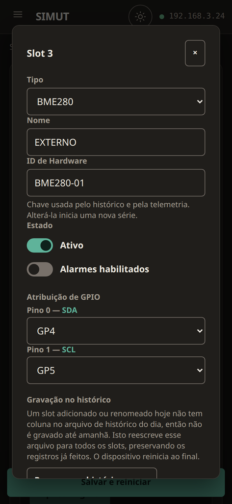

**Figura 29.** Um slot novo de BME280 no celular: dois seletores de pino, SDA e SCL.

Um DS18B20 criado pela página não conhece ainda o número de série da sonda. Na partida seguinte, o aparelho lê esse número (a ROM) no pino, liga o slot a ele e grava. A partir da partida seguinte a essa, o aparelho passa a conferir a sonda (Como o aparelho valida as leituras).

Nota

**Um slot novo e o histórico do dia.** A página avisa que um slot adicionado ou renomeado hoje pode não ser gravado no arquivo de histórico do dia, e oferece **Recompor o histórico agora** para isso.

#### Editar um sensor

1. Na tabela, toque na linha do slot.
2. Mude os campos.
3. Toque em **Concluído**.
4. Toque em **Salvar e reiniciar**.

Para desistir das mudanças de um slot antes de gravar, abra o editor dele e toque em **Descartar alterações**. O botão descarta também as mudanças de calibração desse slot e relê o que está gravado no aparelho.

Ao trocar o **Tipo** de um slot, o aparelho trata o sensor como outro: grava a data da troca como a época do slot (Resetar época do histórico) e apaga a ROM guardada.

#### Desligar sem apagar

Para parar de ler um sensor sem perder sua configuração, desligue **Ativo** e grave com **Salvar e reiniciar**. O slot continua na tabela, sem o ponto verde, e seus GPIOs ficam livres para outros slots.

#### Remover um sensor

1. Na tabela, toque na linha do slot.
2. Toque em **Liberar slot**.
3. Confirme a pergunta **Liberar este slot? Tipo, GPIOs e identificação serão apagados.**
4. Toque em **Salvar e reiniciar**.

O slot volta a ficar vazio e sai da tabela. O histórico já gravado continua no aparelho. As correções de calibração do sensor continuam no arquivo `calib.csv`.

#### Erros ao gravar

O editor confere as regras enquanto você digita e mostra o primeiro problema na linha vermelha:

| Aviso no editor | O que fazer |
| --- | --- |
| **Escolha um tipo antes de ativar este slot.** | Escolha o **Tipo** ou desligue **Ativo** |
| **Atribua um GPIO ao pino** `0 (SDA).` | Escolha o GPIO do pino indicado |
| `GP4` **já está em uso pelo slot** `2.` | Escolha outro GPIO, ou libere o pino no outro slot |

Na gravação, o aparelho confere as mesmas regras e mais algumas. Se alguma falhar, nada é gravado, o aparelho não reinicia, e a página mostra **Falha ao salvar.** (*Save failed.*) seguido do motivo, em inglês:

| Motivo mostrado | Causa |
| --- | --- |
| `slot N: set a type before enabling` | Slot ativo sem tipo |
| `slot N: pin K (SDA) not assigned` | Falta o GPIO de um pino do tipo |
| `slot N: GPx already used by slot M` | Dois slots ativos no mesmo GPIO |
| `slot N: GPx not a sensor pin (0-15)` | GPIO acima de GP15, enviado por outro meio que não a página |
| `slot N: hardware ID cannot be empty on an active slot` | Slot ativo sem **ID de Hardware** |
| `slot N: invalid hwId` | O ID tem caractere fora de letras, dígitos, `_` e `-`, ou mais de 15 caracteres |
| `slot N: invalid name` | O nome tem aspas, barra invertida ou caractere de controle |
| `slot N: driver not in firmware` | Tipo que esta imagem não traz |

### Procurar sondas

O botão **Procurar sondas** varre os pinos do aparelho em busca de sensores ligados. Ele só informa o que encontrou: não cria nem muda nenhum slot.

1. Toque em **Procurar sondas**. O botão fica desativado e a página mostra **Procurando…** (*Scanning…*).
2. Espere o resultado, que chega em poucos segundos. A página espera no máximo 10 s.
3. Leia a lista, como `2 encontrada(s): GP2 (28FF641E8716045C), GP3`.

[output not shown]

A busca por BME280 e BMP280 olha só o par GP4/GP5. Um sensor I²C em outros pinos não aparece na busca, mas funciona se você configurar o slot à mão.

Atenção

**A busca mexe nos pinos.** Para testar cada pino, o aparelho reconfigura um a um os GPIOs de GP0 a GP16, inclusive os de sensores ativos, e a página não recarrega os sensores depois. Desde a v2.7.4, o aparelho devolve ao BMP280 ou BME280 os pinos de I²C de hardware no fim da busca; até a v2.7.3, esse sensor entrava em erro uns 10 s depois e ficava assim até o aparelho perder a energia. O GP16 continua sem voltar ao estado de antes (capítulo 2): faça a busca antes de configurar os slots, ou reinicie o aparelho depois dela.

### Grandezas e unidades

Cada slot informa uma ou mais grandezas, que o aparelho chama de canais:

| Grandeza | Chave | Unidade | Faixa aceita na calibração | Limites de alarme de fábrica |
| --- | --- | --- | --- | --- |
| Temperatura | `temp` | °C | −327,68 a 327,66 | 0 a 40 |
| Umidade | `hum` | % | 0 a 102,3 | 20 a 80 |
| Pressão | `press` | hPa | 0 a 1.638,3 | a faixa inteira |
| Luminosidade | `lux` | lx | 0 a 167.772,15 | a faixa inteira |

A chave é o nome da grandeza na interface de programação, na telemetria e no arquivo de calibração. Na página, os rótulos curtos são **Temp**, **Umid**, **Press** e **Luz**.

A luminosidade existe na tabela de grandezas, mas nenhum dos quatro tipos de sensor a informa na v2.7.1.

### Leitura e histórico

O aparelho lê cada sensor no seu próprio ritmo e grava o histórico no ritmo do **Intervalo Histórico**. São duas coisas diferentes.

**Ritmo de leitura.** É fixo por tipo:

| Tipo | Pausa entre leituras |
| --- | --- |
| DS18B20 | 1 s, mais os 750 ms da conversão |
| DHT22 | 2 s |
| BME280 e BMP280 | 5 s |

**Média.** Cada grandeza guarda as últimas 10 leituras. Com as 10 guardadas, o aparelho descarta as 2 menores e as 2 maiores e tira a média das 6 restantes. Antes disso, logo depois da partida, usa a média simples do que tem. A correção de calibração é aplicada sobre essa média. O resultado é o valor que o painel, a página e a telemetria mostram.

**Histórico.** A cada **Intervalo Histórico**, o aparelho grava um registro com o valor corrigido de cada grandeza naquele instante. Um sensor em erro entra no registro sem valor. O primeiro registro depois de um reinício não espera o intervalo inteiro, desde que o relógio já esteja acertado.

air No Air, o aparelho lê os sensores a cada despertar (capítulo 19).

### Como o aparelho valida as leituras

Uma leitura falha quando o sensor não responde, quando a conferência dos dados falha ou quando o valor está fora do que o aparelho aceita:

| Tipo | O que o aparelho confere |
| --- | --- |
| DS18B20 | O CRC da leitura. Temperatura fora de −50 a 150 °C é recusada. A cada 5 leituras, confere se a sonda no pino é a mesma cuja ROM está gravada |
| DHT22 | A soma de verificação. Sem resposta em 150 ms, a leitura falha |
| BME280 e BMP280 | Temperatura fora de −40 a 85 °C faz a leitura falhar. Umidade fora de 0 a 100 % e pressão fora de 300 a 1.100 hPa são descartadas, só naquela grandeza |

Um valor que não é número (infinito, indefinido) nunca entra na média.

**Estado de erro.** Um sensor entra em erro depois de 3 falhas seguidas e sai dele depois de 5 leituras boas seguidas. Enquanto está em erro, o aparelho não usa as leituras dele.

**Sonda trocada.** Um DS18B20 com ROM gravada só é lido se a sonda no pino for a mesma. Se outra sonda aparecer, o slot entra em erro na hora, em quarentena. A cada 10 ciclos de leitura, o aparelho relê a ROM do pino. Quando a sonda certa volta, a quarentena acaba sozinha e o log registra `Hardware match restored`. Para aceitar a sonda nova, use **Adotar a sonda ligada aqui** (Operações de hardware). Um DS18B20 sem ROM gravada aceita qualquer sonda no pino.

O log de eventos registra a entrada em erro, com o GPIO do sensor (capítulo 16):

| Código | Evento | Causa típica |
| --- | --- | --- |
| 101 | Timeout de sensor | DHT22 sem resposta |
| 102 | Erro de checksum | DHT22 com dados corrompidos |
| 103 | Erro de CRC | DS18B20 com dados corrompidos ou sem resposta |
| 104 | Sensor fora de range | DS18B20 fora de −50 a 150 °C |
| 105 | Divergência de hardware | Outra sonda no pino de um DS18B20 |
| 999 | Erro desconhecido | Falha de leitura de um BME280 ou BMP280, ou falha ao ler a ROM do DS18B20 |
| 100 | Sensor recuperado | 5 leituras boas depois de um erro |

#### Como o erro aparece

Nota

**As telas desta seção são as do painel original (Pico W).** No Pico 2 W, veja o capítulo 11A.

- **Painel** release: o cartão do sensor mostra **Erro** (*ERROR*) em letras grandes, no lugar do valor. O alarme de falha deixa o cartão âmbar (capítulo 7).
- **LCD** alpha: quando o LCD chega ao sensor em erro, mostra `ERRO` em letras grandes. O mesmo `ERRO` aparece quando não há nenhum sensor ativo.
- **Interface web**: na tabela de sensores do **Painel de Controle**, o ponto fica vermelho e a leitura mostra `Error` (capítulo 13).
- **Histórico**: os registros do período em erro ficam sem valor para aquele sensor.

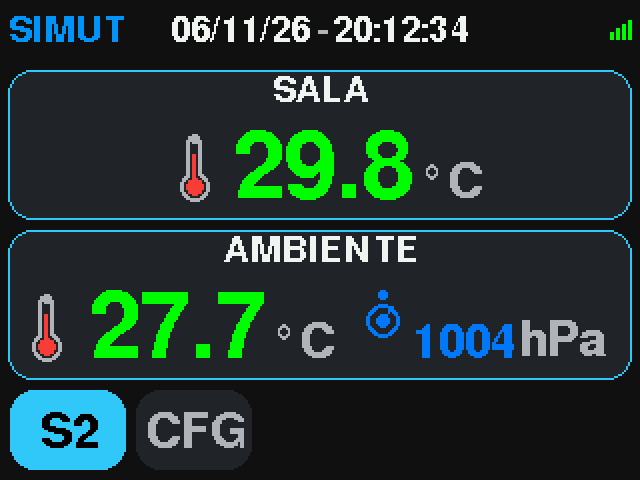

**Figura 32.** A tela inicial do painel com dois sensores lendo normalmente.

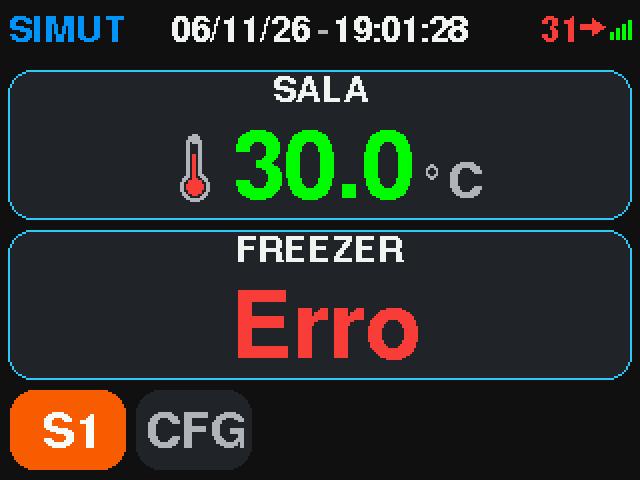

[figure not shown]

**Figura 34.** O LCD do alpha com o sensor em erro.

### Operações de hardware

As operações da seção **Hardware** do editor agem no aparelho na hora. Elas não passam por **Salvar e reiniciar**.

#### Adotar a sonda ligada aqui

Só aparece em slots DS18B20. Use depois de trocar uma sonda, quando o slot está em quarentena por divergência de hardware.

1. Abra o editor do slot.
2. Toque em **Adotar a sonda ligada aqui** (*Adopt the probe wired here*).

O aparelho lê a ROM da sonda no GPIO do slot, liga o slot a ela, grava e recarrega os sensores: a leitura segue com a sonda nova na hora, sem reiniciar. O GPIO do slot não muda. Se a ROM já constar do arquivo `calib.csv`, o slot recebe o ID de hardware e o nome guardados para ela; se não constar, recebe o ID `LIB_SENS`. Quando o ID muda, o aparelho grava a data como a época do slot (Resetar época do histórico).

| Mensagem | Significado |
| --- | --- |
| **Slot vinculado à sonda encontrada nele.** | A sonda foi adotada |
| **Nenhuma sonda respondeu neste GPIO.** | Nada respondeu no GPIO do slot |
| **A sonda respondeu com uma ROM inválida.** | A ROM lida falhou na conferência |
| **Salve antes este slot como um DS18B20 ativo.** | O slot gravado no aparelho não é um DS18B20 ativo: por exemplo, o tipo foi escolhido no editor e ainda não foi salvo |

Nota

**Até a v2.11.0, a adoção lia o GPIO de mesmo número que o slot** e gravava esse número como pino do slot. Num slot ligado a um GPIO de outro número, ela lia o pino errado e mudava o pino do slot. E a leitura em andamento seguia com a ROM antiga: a cada 5 leituras a divergência voltava, até o aparelho reiniciar.

#### Resetar época do histórico

Grava o instante atual como a época do slot: a data em que o sensor atual começou nele. Use quando trocar o sensor físico de um slot, para registrar a troca.

1. Abra o editor do slot.
2. Toque em **Resetar época do histórico** (*Reset history epoch*).
3. Confirme a pergunta. A página mostra **Época do histórico resetada.**

Nota

**Na v2.7.1, a época não muda os gráficos.** O aparelho grava a data, mas nenhum gráfico, exportação ou envio de telemetria a usa. Os registros do sensor antigo e do novo aparecem como uma série só. Para ver só um deles, escolha a janela pelo período ou pelo calendário (capítulo 15).

#### Recompor o histórico

O botão **Recompor o histórico agora** (*Rebind history now*) vale para o aparelho inteiro, não só para o slot aberto. Ele reescreve o arquivo de histórico do dia para os slots gravados, mantém os registros já feitos e reinicia o aparelho no fim. O histórico está no capítulo 15.

1. Grave antes as mudanças pendentes. Com alguma pendente, a página recusa e mostra **Salve e Reinicie antes — recompor agora usaria a configuração anterior.**
2. Toque em **Recompor o histórico agora** e confirme.
3. Espere a mensagem **Histórico reescrito** seguida da contagem. A página se recarrega cerca de 25 s depois.

Se o arquivo do dia não puder ser lido, a página pergunta se deve recriá-lo vazio. Recriar perde os registros de hoje; os dias anteriores ficam intactos. Se o aparelho não responder, a página mostra **Sem resposta do dispositivo. Recarregue a página e confira o log antes de tentar de novo.**

### Calibração

A calibração corrige a leitura de um sensor para que ela coincida com a de um instrumento de referência. Cada grandeza de cada sensor tem a sua correção: um BME280 tem três, uma para temperatura, uma para umidade e uma para pressão.

A correção é feita por pontos. Cada ponto liga um valor bruto, o que o sensor leu, ao valor de referência, o que o instrumento confiável mostrou no mesmo momento. Uma grandeza aceita até 5 pontos.

| Pontos | O que o aparelho faz |
| --- | --- |
| Nenhum | Nenhuma correção. Vale a leitura do sensor |
| 1 | Soma uma diferença constante, o offset, a toda leitura |
| 2 a 5 | Muda a correção entre os pontos, conforme a interpolação escolhida |

Abaixo do menor valor bruto e acima do maior, a correção fica igual à do ponto da ponta. O aparelho nunca projeta uma inclinação para fora da faixa medida.

#### Reta ou Suave

A **Interpolação** (*Interpolation*) define como a correção passa de um ponto ao outro:

- **Reta** (*Straight*): linhas retas entre os pontos. É a escolha de fábrica.
- **Suave** (*Smooth*): uma curva cúbica monótona, do tipo PCHIP. Ela passa por todos os pontos sem ultrapassar nenhum deles entre um ponto e o seguinte.

A escolha **Suave** precisa de 3 pontos ou mais. Com menos, ela se comporta como **Reta**, e a página avisa: **Suave é uma cúbica monótona: dobra pelas âncoras sem jamais ultrapassá-las. Precisa de 3+ pontos; com menos, comporta-se como reta.**

#### Requisitos

- **Permissões.** A conta precisa de **Sistema** PERM_SYS_CONFIG, para abrir a página, e de **Calibração** PERM_CALIB, para ver e gravar o bloco.
- **Relógio acertado.** Sem o relógio acertado, por NTP ou à mão (capítulo 10), o aparelho recusa a gravação da calibração, e o bloco avisa em vermelho: **NTP não sincronizado.** Até a v2.8.0 a recusa nunca acontecia, porque o aparelho dava o relógio por sincronizado mesmo sem acerto.
- **Slot ativo e gravado.** O bloco só aparece em slots ativos já gravados no aparelho. Num slot novo, grave o slot primeiro e calibre depois.
- **Uma leitura ao vivo**, para os pontos em que você deixar o valor bruto vazio.
- **Uma gravação a cada 5 s.** O aparelho recusa uma segunda gravação de calibração antes disso.

#### Calibrar um sensor

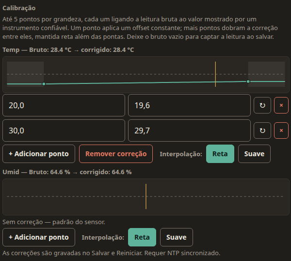

**Figura 35.** O bloco Calibração de um DHT22. Cada grandeza tem sua linha de leitura, o mini gráfico da correção e seus pontos.

Para cada grandeza, o bloco mostra:

- uma linha com o nome da grandeza, a leitura **Bruto** (*Raw*) e a leitura **corrigido** (*corrected*), como `Temp — Bruto: 23.61 °C → corrigido: 23.40 °C`;
- um mini gráfico da correção: a linha do zero, que é o sensor sem correção, e a curva com os pontos;
- sem pontos, **Sem correção — padrão do sensor.** (*No correction — sensor default.*), ou **Offset constante** (*Constant offset*) seguido do valor, quando a correção é um offset antigo gravado sem ponto de origem;
- os pontos, um por linha, cada um com **Bruto**, **Referência** (*Reference*), o botão **↻** (**Usar a leitura bruta atual**) e o botão **×** (**Remover este ponto**);
- **+ Adicionar ponto** (*Add point*), até 5 pontos;
- **Remover correção** (*Remove correction*);
- **Interpolação:** com **Reta** e **Suave**.

Para calibrar:

1. Ponha o sensor e o instrumento de referência no mesmo ambiente e espere os dois estabilizarem.
2. Abra o editor do slot.
3. Na grandeza a corrigir, toque em **+ Adicionar ponto**.
4. Toque em **↻** para copiar a leitura bruta atual para **Bruto**. Se preferir, deixe **Bruto** vazio: o aparelho capta a leitura bruta no momento da gravação.
5. Digite em **Referência** o valor que o instrumento mostra.
6. Para mais pontos, mude o ambiente (por exemplo, outra temperatura), espere estabilizar e repita os passos 3 a 5.
7. Escolha **Reta** ou **Suave**.
8. Confira se a linha de aviso vermelha do bloco está vazia.
9. Toque em **Concluído** e depois em **Salvar e reiniciar**.

Os pontos não precisam estar em ordem: o aparelho os ordena pelo valor bruto. Na gravação, o aparelho grava a calibração primeiro e aplica a correção aos sensores; em seguida grava o resto e reinicia. O log de eventos registra o código 407, **Sensores calibrados**.

Para tirar a correção de uma grandeza, toque em **Remover correção** e grave.

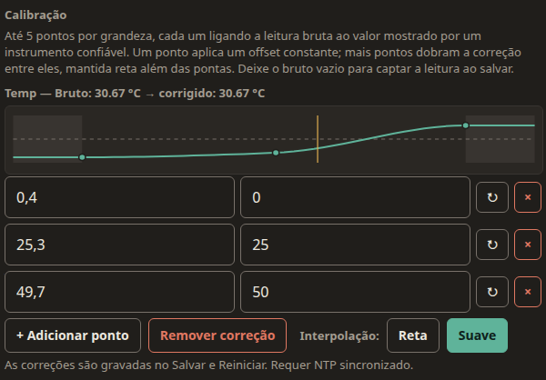

**Figura 36.** Uma correção Suave com três pontos: o mini gráfico mostra a curva passando pelos pontos sem ultrapassá-los.

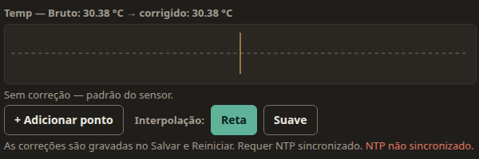

**Figura 37.** Sem NTP, o bloco avisa em vermelho que a gravação será recusada.

#### Erros da calibração

O bloco confere os pontos enquanto você digita e mostra o primeiro problema, precedido do nome da grandeza:

| Aviso | O que fazer |
| --- | --- |
| **no máximo 5 pontos.** | Remova um ponto |
| **todo ponto precisa de bruto e referência numéricos.** | Preencha **Referência** com um número; **Bruto** vazio ou numérico |
| **sem leitura ao vivo para captar — preencha o valor bruto.** | O sensor não tem leitura agora. Digite o valor bruto |
| **ponto fora da faixa plausível** seguido da faixa | Corrija o valor; as faixas estão em Grandezas e unidades |
| **dois pontos com o mesmo valor bruto.** | Dois pontos com o mesmo bruto, até a segunda casa decimal. Remova um |

Na gravação, uma recusa do aparelho aparece como **Erro na calibração:** (*Calibration error:*) seguido do motivo, e nada é gravado:

| Motivo | Causa |
| --- | --- |
| `NTP not synced` | Relógio não sincronizado por NTP |
| `rate limited` | Menos de 5 s desde a gravação de calibração anterior |
| `slot N temp: point out of range` | Ponto fora da faixa da grandeza |
| `slot N temp: duplicate calibration points` | Dois pontos com o mesmo valor bruto |
| `slot N temp: no live reading to capture` | Bruto vazio e o sensor sem leitura |
| `Forbidden` | A conta não tem a permissão **Calibração** |

Se a gravação da calibração demorar mais de 30 s, a página mostra **Tempo esgotado na calibração. Tente novamente.**

#### O arquivo calib.csv

As correções ficam no arquivo `/calib.csv`, na raiz do sistema de arquivos do aparelho, e não na configuração. O arquivo aparece na página **Arquivos** (capítulo 17).

A primeira linha é `VERSION,` seguida de um número que cresce a cada gravação. As outras linhas têm uma correção cada:

```
VERSION,1790000000
28FF641E8716045C,FREEZER-1,Freezer da sala 2,-18.40,-18.00,4.10,4.00
E6614103E7512B29,tSALA-1,Sala,cub,15.20,15.00,22.80,22.50,30.10,30.00
E6614103E7512B29,uSALA-1,Sala,55.00,52.00
```

| Coluna | Conteúdo |
| --- | --- |
| 1 | A ROM do DS18B20; para os outros tipos, o número de série da placa |
| 2 | O ID de hardware; para os outros tipos, a letra da grandeza (`t`, `u`, `p`) seguida do ID |
| 3 | O nome |
| 4 | `cub` quando a interpolação é **Suave**; ausente quando é **Reta** |
| Resto | Os pares bruto e referência, um número por coluna |

Uma linha de DS18B20 sem pontos continua no arquivo: ela guarda a associação entre a ROM, o ID e o nome, que a adoção de sonda consulta.

Você pode enviar um `calib.csv` pela página **Arquivos**. O aparelho só o aceita se o número de `VERSION` for maior que o do arquivo atual; caso contrário, descarta o envio.

Perigo

**No Pico W, a atualização de firmware apaga o calib.csv.** A atualização pela web reformata o sistema de arquivos, e só a configuração é preservada. O arquivo de calibração se perde, e os sensores voltam a ler sem correção. O backup (`.bkp`), que a página de atualização baixa antes de começar, leva o arquivo: restaure-o depois da atualização (capítulo 17). No Pico 2 W o arquivo fica, porque o sistema de arquivos fica intocado (capítulo 26).

Voltar ao sumário

Capítulo 7

## Alarmes, sons e janelas de manutenção

Este capítulo mostra quando o aparelho dispara um alarme, o que acontece no painel, na cigarra e na interface web, e como silenciar, desligar e suspender alarmes com uma janela de manutenção. É para quem opera o aparelho no dia a dia e para quem define os limites; o envio dos alarmes a um servidor está no capítulo 22.

### Os dois tipos de alarme

O aparelho tem dois alarmes por sensor, independentes um do outro:

| Alarme | Quando dispara | Pode ser desligado |
| --- | --- | --- |
| **Limite** | Uma grandeza do sensor sai da faixa entre o mínimo e o máximo configurados | Sim, por sensor (Ligar e desligar) |
| **Falha** | O sensor entra em estado de erro: 3 leituras seguidas falharam, ou outra sonda apareceu no pino de um DS18B20 (capítulo 6) | Não. Pode ser suspenso por uma janela de manutenção ou calado até o sensor voltar |

Nenhum dos dois dispara num slot inativo, nem num slot com a janela de manutenção aberta (Janelas de manutenção).

air O Air não tem painel nem cigarra. Nele, os alarmes só saem pela linha de alarmes (capítulo 22).

### Limites por grandeza

Cada grandeza de cada sensor tem um mínimo e um máximo. O alarme de limite dispara quando qualquer grandeza do sensor fica abaixo do mínimo ou acima do máximo. Um BME280, por exemplo, tem três pares de limites: temperatura, umidade e pressão.

O valor comparado é o valor corrigido que o painel mostra, depois da média e da calibração (capítulo 6).

Limites de fábrica, em todo slot novo:

| Grandeza | Mínimo | Máximo |
| --- | --- | --- |
| Temperatura | 0 °C | 40 °C |
| Umidade | 20 % | 80 % |
| Pressão | 0 hPa | 1.638,3 hPa |
| Luminosidade | 0 lx | 167.772,15 lx |

As regras dos limites:

- **Mínimo abaixo do máximo.** Se o mínimo ficar igual ou maior que o máximo, o aparelho sobe o máximo para o mínimo mais 0,1.
- **Dentro da faixa da grandeza.** Cada grandeza aceita limites só dentro da sua faixa plausível (capítulo 6). Pela web, um limite fora dela faz o aparelho recusar a gravação inteira, com `Alarm limit outside channel range`.
- **Uma casa decimal.** A página e o painel ajustam os limites em passos de 0,1.

Os limites podem ser mudados na página **Alarmes e Sons** (A página Alarmes e Sons) e no painel (Limites no painel).

### Ligar e desligar os alarmes de um sensor

Desligar os alarmes de um sensor desliga só o alarme de limite dele. O alarme de falha continua ativo: uma falha de comunicação não é um limite que se possa desligar.

Há quatro lugares para isso:

| Onde | Como | Grava |
| --- | --- | --- |
| Página **Alarmes e Sons** | A chave no topo do cartão do sensor | Com os botões de gravação, sem reiniciar |
| Editor de slot, em **Configurações** | **Alarmes habilitados** | Só com **Salvar e reiniciar** |
| Painel, menu do sensor | A linha **Alarmes** | Na hora |
| Painel, tela de alarme | **Desativar**, com PIN | Na hora |

De fábrica, os alarmes de todo slot vêm ligados. Religar os alarmes de um sensor, pela web ou pelo painel, também desfaz o silêncio do alarme de falha dele (Desativar).

### O que acontece quando um alarme dispara

Nota

**As telas desta seção são as do painel original (Pico W).** No Pico 2 W, veja o capítulo 11A.

Quando um alarme dispara, o aparelho:

- toca a cigarra, com a melodia e o volume de alarme (Sons);
- no painel, pisca o cartão do sensor: para limite, em amarelo no painel original e em vermelho na Ângulo; para falha, em âmbar;
- no painel, leva o sensor em alarme para o cartão de baixo, a menos que ele já esteja fixado no cartão de cima;
- registra no log de eventos o código 470, **Alarme disparado**;
- se a linha de alarmes estiver ligada, envia o registro ao servidor (capítulo 22).

Quando nenhum sensor está mais em alarme, a cigarra para, os cartões param de piscar e o log registra o código 471, **Alarme zerado**.

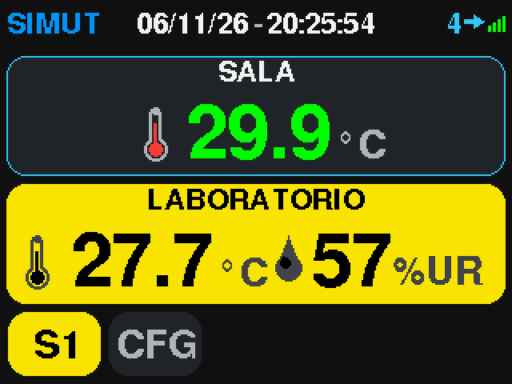

**Figura 38.** Um alarme de limite no painel original: o cartão do sensor pisca em amarelo.

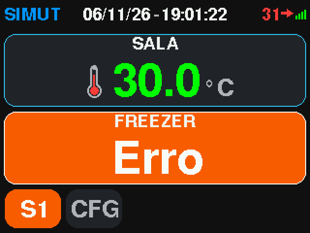

**Figura 39.** Um alarme de falha no painel: o cartão pisca em âmbar e mostra Erro no lugar do valor.

#### No painel

release Toque no cartão que pisca para abrir a tela de alarme daquele sensor. O título mostra `!` seguido do nome do sensor, e três botões:

| Botão | O que faz | Exige |
| --- | --- | --- |
| **Silenciar 120s** (*Silence 120s*) | Cala a cigarra e para a piscada por 120 s (Silenciar) | Nada |
| **Desativar** (*Deactivate*) | Desliga o alarme daquele sensor (Desativar) | PIN de uma conta com a permissão **Bloqueio (painel)** |
| **Min/Max** | Volta à tela inicial com o cartão do sensor mostrando o mínimo e o máximo do dia | Nada |

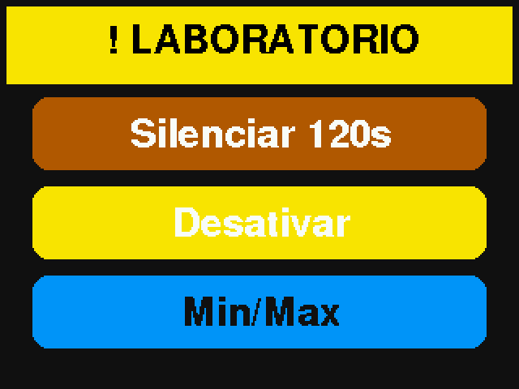

**Figura 40.** A tela de alarme de um sensor, com Silenciar 120s, Desativar e Min/Max.

#### No LCD

alpha A imagem alpha tem cigarra, mas o LCD não mostra alarmes e não há como silenciar no aparelho. A cigarra toca até o valor voltar à faixa, até alguém desligar os alarmes do sensor pela web, ou até alguém ligar o **Mudo Global** (Sons pela web). O LCD mostra `ERRO` para um sensor em falha (capítulo 6).

#### Na interface web

A interface web não mostra alarmes de limite. No **Painel de Controle**, um sensor em falha aparece com o ponto vermelho e `Error` (capítulo 13); um sensor fora dos limites aparece com a leitura normal.

release O espelho do painel, no **Painel de Controle**, mostra o painel como ele está, inclusive o cartão piscando (capítulo 13).

Para acompanhar alarmes de longe, use a linha de alarmes (capítulo 22).

### Silenciar

**Silenciar 120s** cala o alarme por 120 s. Durante esse tempo:

- a cigarra para;
- os cartões param de piscar;
- a barra de cima do painel mostra **Silenciado:** seguido dos segundos que faltam, como `Silenciado: 97s`;
- nenhum alarme toca, nem um alarme novo de outro sensor.

O silêncio vale para todos os sensores, mesmo tocado a partir da tela de um só. Ele não exige PIN. O log registra o código 447, **Alarme silenciado via UI**, e a linha de alarmes recebe um registro de silêncio do sensor da tela (`alarm_sil` ou `err_sil`).

Quando os 120 s acabam, o log registra o código 448, **Silenciamento de alarme expirou**. Se algum sensor ainda estiver em alarme, a cigarra volta a tocar e o cartão volta a piscar. Se todos os alarmes acabarem antes, o silêncio é cancelado (código 472, **Silenciamento cancelado**).

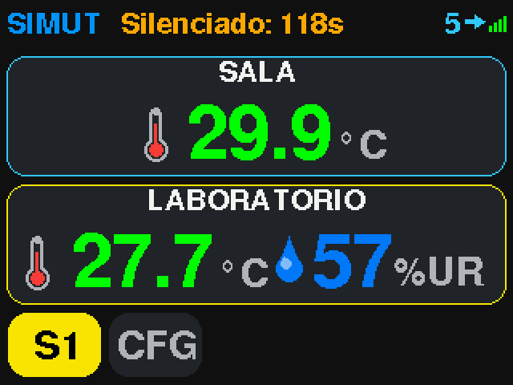

**Figura 41.** O painel durante o silêncio: a contagem na barra de cima e o cartão parado.

### Desativar

**Desativar** desliga o alarme do sensor da tela, e só dele. O efeito depende do alarme que está ativo:

- **Limite:** desliga os alarmes do sensor, como a linha **Alarmes** do menu do sensor. A mudança é gravada e continua valendo depois de um reinício. O log registra o código 456, **Alarmes do sensor bloqueados pelo painel**.
- **Falha:** cala só a falha daquele sensor, e o limite continua armado. O silêncio da falha dura até o sensor voltar a ler; se ele falhar de novo, o alarme volta. Religar os alarmes do sensor também o desfaz, e um reinício também. O log registra o código 449, **Todos alarmes desativados (RAM)**.

Para desativar:

1. Toque no cartão que pisca.
2. Toque em **Desativar**.
3. Escolha a conta na lista **Quem está usando o painel?** (capítulo 8).
4. Digite o PIN.

Se a conta não tiver a permissão **Bloqueio (painel)** PERM_ALARM_BLOCK, o painel mostra **Sem permissão** e toca o som de erro; o log registra o código 458, **Ação do painel recusada: sem permissão**. Com a permissão, a cigarra para, o painel volta à tela inicial e a linha de alarmes recebe um registro `alarm_off` ou `err_off` com o nome da conta.

### A página Alarmes e Sons

A página **Alarmes e Sons** (*Alarms & Sounds*, rota `/alarms`) exige a permissão **Sistema** PERM_SYS_CONFIG. Ela tem duas seções: **Limites de Alarme** e **Configuração de Sons**.

A página não tem botão próprio de gravar. As mudanças ficam preparadas na aba e são gravadas pelos botões da barra de topo (capítulo 5):

- limites e chaves de alarme valem sem reiniciar: **Testar** e **Aplicar agora** funcionam para eles;
- mudanças de som exigem reinício, e a barra oferece só **Salvar e reiniciar**.

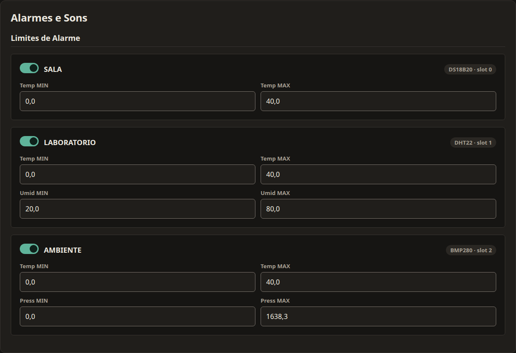

**Figura 42.** A seção Limites de Alarme: um cartão por sensor ativo, com a chave de alarme e um par de campos por grandeza.

#### Limites de Alarme

A seção mostra um cartão por sensor ativo. Sem sensores ativos, mostra **Nenhum sensor configurado.** (*No sensors configured.*); os sensores são criados na página **Configurações** (capítulo 6).

Cada cartão tem:

| Elemento | O que é |
| --- | --- |
| Chave, à esquerda do nome | Liga ou desliga os alarmes de limite do sensor |
| Nome | O nome do slot |
| Tipo e slot | Como `BME280 · slot 4` |
| **Temp MIN** e **Temp MAX** | Os limites de temperatura, em °C |
| **Umid MIN** e **Umid MAX** | Os limites de umidade, em %, só em sensores com umidade |
| **Press MIN** e **Press MAX** | Os limites de pressão, em hPa, só em sensores com pressão |

Ao digitar um mínimo igual ou maior que o máximo, a página sobe o máximo para o mínimo mais 0,1; ao digitar um máximo igual ou menor que o mínimo, desce o mínimo.

Para mudar um limite:

1. Abra **Alarmes e Sons**.
2. Digite o novo valor no campo.
3. Toque em **Aplicar agora** na barra de topo.

O aparelho passa a usar o limite novo na verificação seguinte, sem reiniciar.

Nota

**Limites mudados pela web não vão para a linha de alarmes.** Só as mudanças de limite feitas no painel geram o registro `alarm_lim`, com o nome da conta (capítulo 22). Pela web, a mudança fica no log de eventos como alteração de configuração.

#### Configuração de Sons

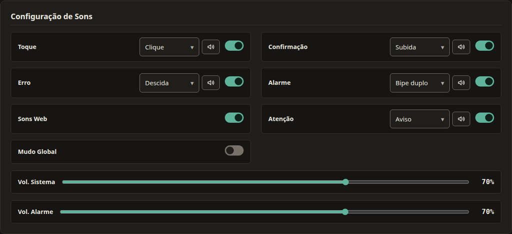

**Figura 43.** A seção Configuração de Sons com os valores de fábrica: todos os sons ligados, volumes em 70 %.

| Linha | Controles | Fábrica |
| --- | --- | --- |
| **Toque** (*Touch*) | Melodia, botão de teste, chave | Ligado, **Clique** |
| **Confirmação** (*Confirm*) | Melodia, botão de teste, chave | Ligado, **Subida** |
| **Erro** (*Error*) | Melodia, botão de teste, chave | Ligado, **Descida** |
| **Alarme** (*Alarm*) | Melodia, botão de teste, chave | Ligado, **Bipe duplo** |
| **Sons Web** (*Web Sounds*) | Chave | Ligado |
| **Atenção** (*Attention*) | Melodia, botão de teste, chave | Ligado, **Aviso** |
| **Mudo Global** (*Global Mute*) | Chave | Desligado |
| **Vol. Sistema** (*System Volume*) | Controle deslizante, de 0 a 100 %, em passos de 5 | 70 % |
| **Vol. Alarme** (*Alarm Volume*) | Controle deslizante, de 0 a 100 %, em passos de 5 | 70 % |

O botão de teste toca a melodia escolhida no navegador, não na cigarra do aparelho, no volume do controle correspondente. Os detalhes de cada som estão em Sons.

Ligar **Mudo Global** desliga as outras seis chaves; ligar qualquer uma delas desliga **Mudo Global**.

Nota

**Até a v2.9.0, uma mudança de som preparada já valia no aparelho.** O ensaio que a página faz para decidir se a mudança exige reinício aplicava os sons à cigarra antes da gravação: ligar **Mudo Global** na página calava até um alarme tocando, mesmo que você desistisse. Desde a v2.10.0, o ensaio não mexe no som em uso, e a mudança vale depois do reinício que **Salvar e reiniciar** faz.

### O menu de alarmes do painel

release No painel, os alarmes ficam no item **Limites de Alarme** do menu de configurações. O item aparece para contas com pelo menos uma das três permissões de painel:

| Permissão | Nome na página Usuários | Libera |
| --- | --- | --- |
| PERM_ALARM_LIMITS | **Limites (painel)** | A linha **Limites de alarme** do menu do sensor |
| PERM_ALARM_BLOCK | **Bloqueio (painel)** | A linha **Alarmes** e o botão **Desativar** da tela de alarme |
| PERM_MAINT | **Manut. (painel)** | A linha **Manutenção** |

Para abrir o menu, toque no botão de configurações da tela inicial, escolha a conta e digite o PIN (capítulo 8). O que cada conta pode fazer é decidido pelas permissões da conta que o PIN identificou.

#### A lista de sensores

A tela **Limites de Alarme** lista os sensores ativos, quatro por página, cada um com o nome e o estado dos alarmes: **SIM** (ligados) ou **NÃO** (desligados). As setas do rodapé mudam a seleção e **SAIR** volta ao menu.

Toque num sensor para selecioná-lo; toque de novo para abrir o menu dele.

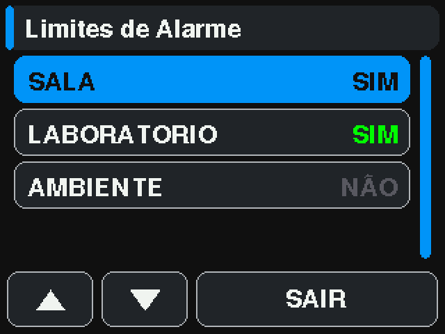

**Figura 44.** A lista de sensores do menu de alarmes, com o estado SIM ou NÃO de cada um.